# Njoroge et al 2023 meta-analysis

Denis Mburu Njoroge, Gbadamassi G.O. Dossa, Juan Zuo

(Created on April 20 2022 and last updated on 周三 8月 14 2024 21:52:54)

# 1 Introduction

This script records the meta-analysis based on the manuscript “The effects of invertebrates on wood decomposition across the world” submitted to Biological journal. This meta-analysis aims to quantitatively estimate the contribution of invertebrates to wood decomposition globally.

# 2 How we acquired the data

In November 2021, we carried out a litterature search for studies on woody debris (WD) decomposition and the contribution of invertebrates to WD decomposition in the Scopus database and ISI web of science. We used “litsearchr” package (Grames et al 2018) to refine the search language (see procedure in flow chart below), then we later used the refined search terms to redo search in the above mentioned databases.

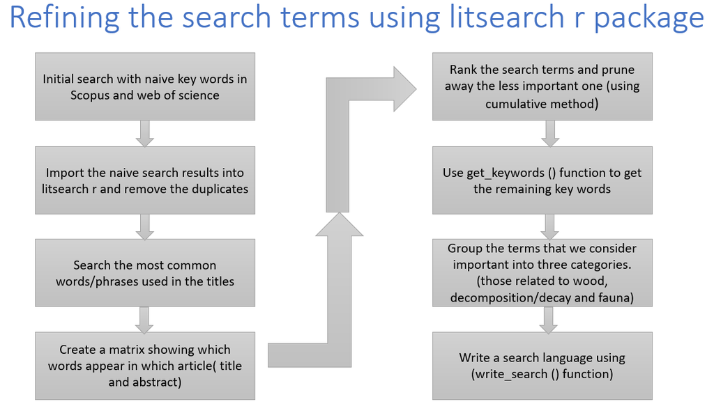

The final search terms from litsearchr were as given below

*“coarse woody OR”woody debris” OR “woody material” OR “woody plant” OR roots OR “fine wood debris” AND “decay rates” OR “decay resistance” OR decomposition OR degradation AND “beetle assemblages” OR “beetle attack” OR “beetle communities” OR “beetle diversity” OR “beetle infestation" OR”beetle outbreak” OR “beetle outbreaks” OR “beetle species” OR “benthic invertebrate” OR “benthic macroinvertebrate” OR “coptotermes formosanus” OR “daphnia magna” OR “earthworm activity” OR “earthworm species” OR “folsomia candida” OR “formosan subterranean” OR “formosanus shiraki” OR “heterodera schachtii” OR “higher termite” OR “insect outbreak” OR “insect pests” OR “insect species” OR “invertebrate communities” OR “lower termite” OR “macroinvertebrate community” OR “matter decomposition” OR “nematode communities” OR “nematode community” OR “nematode control” OR “nematode meloidogyne” OR “nematode populations” OR “oribatid mites” OR “parasitic nematode” OR “parasitic nematodes” OR “root-knot nematode” OR “root-knot nematodes” OR “saproxylic beetle” OR “saproxylic beetles” OR “saproxylic insect” OR “saproxylic insects” OR “saproxylic species” OR “subterranean termite” OR “subterranean termites” OR “termite assemblage” OR “termite attack” OR “termite coptotermes” OR “termite feeding” OR “termite resistance” OR “termite reticulitermes” OR “termite species” OR “wood-feeding termite” OR “wood-feeding termites” OR fauna OR arthropod”*

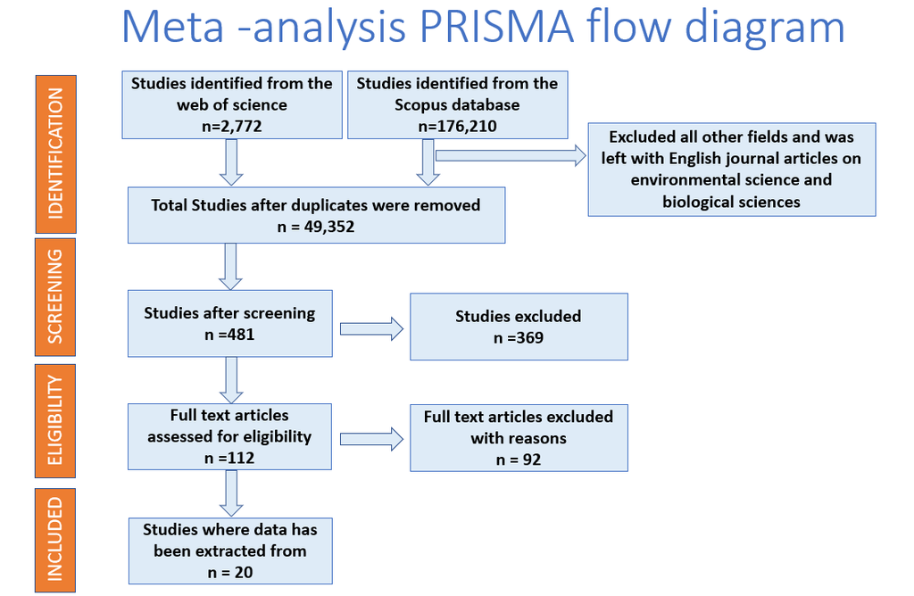

. Figure S2 PRISMA flowchart of diagram showing the steps followed for the inclusion of studies in our database.

We aimed at testing the following hypothesis as indicated in our hypothetical framework shown below.

We hypothesize that: (i) the invertebrate effect on WD decomposition is climate dependent and variations in deadwood traits will constrain the invertebrate effect with larger effect sizes in warmer climate zones (i.e. stronger in magnitude in tropical zones); (ii) the effect of invertebrates will be greater in WD with a larger diameter; (iii) bark presence will increase the effect of invertebrates on wood decomposition; (iv) the effects of invertebrates will be greater in natural non-processed wood, either with or without bark than in processed wood (e.g. blocks, stakes, dowels, mostly without bark) as the latter may be perceived by invertebrates as novel materials; (v) the effect of invertebrates on WD decomposition will be greater in angiosperms than in gymnosperms, as the powerful anti-herbivory defences present in gymnosperms will deter invertebrate decomposers.

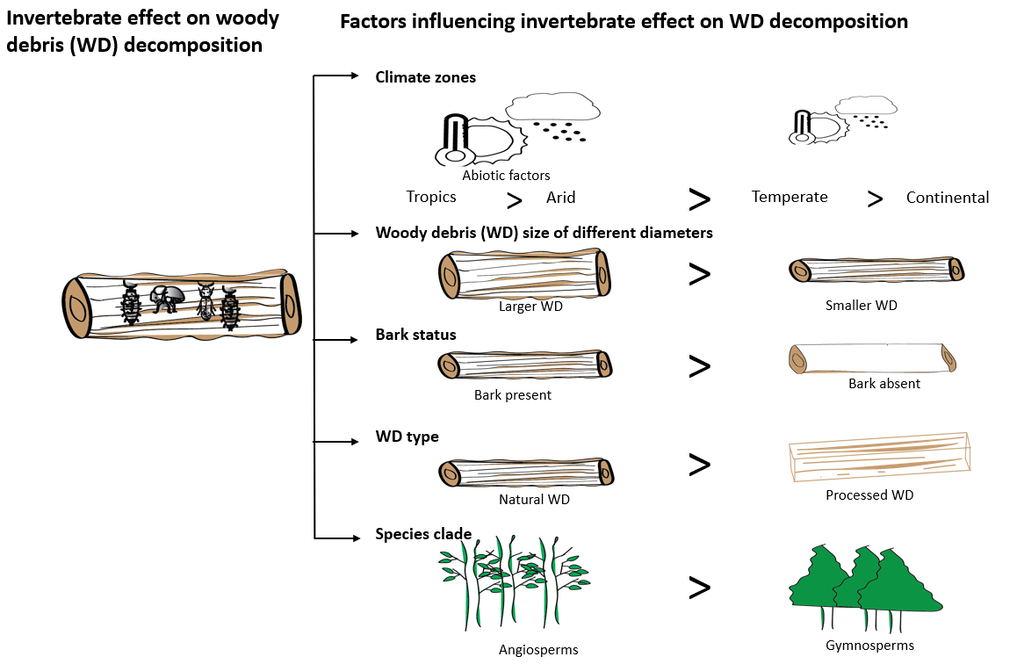

**Figure S1 Conceptual framework on which our meta-analysis is based.**

The sections below shows how we analysed the extracted data how we obtained/plotted all the figures and tables shown in the submitted manuscript.

## 2.1 Import the extracted data for the meta-analysis

```r
wood_meta<-read.csv("Njoroge_et_al_2023_meta.csv", header = TRUE, sep = ",", quote = "\"",
              dec = ".", fill = TRUE, comment.char = "",fileEncoding = 'latin1')
summary(wood_meta)
```

```
##  Publication_number  Reference           Journal             Study
##  Min.   : 1.00      Length:1767        Length:1767        Length:1767
##  1st Qu.: 9.00      Class :character   Class :character   Class :character
##  Median : 9.00      Mode  :character   Mode  :character   Mode  :character
##  Mean   :11.87
##  3rd Qu.:20.00
##  Max.   :20.00
##
##   Case_study          Country          lab_or_field_experiment
##  Length:1767        Length:1767        Length:1767
##  Class :character   Class :character   Class :character
##  Mode  :character   Mode  :character   Mode  :character
##
##
##
##
##  Original_Site      original_decimals_latitude original_decimals_longtitude
##  Length:1767        Min.   :-45.529            Min.   :-130.17
##  Class :character   1st Qu.: -3.255            1st Qu.: -65.33
##  Mode  :character   Median : 18.320            Median :  10.98
##                     Mean   : 15.191            Mean   :  16.81
##                     3rd Qu.: 41.303            3rd Qu.: 101.63
##                     Max.   : 64.190            Max.   : 174.60
##
##  Original_Altitude.m.a.s.l.. Incubation_Site    incubation_decimal_latitudes
##  Min.   :190                 Length:1767        Min.   :-45.529
##  1st Qu.:865                 Class :character   1st Qu.: -3.255
##  Median :865                 Mode  :character   Median : 18.320
##  Mean   :773                                    Mean   : 15.191
##  3rd Qu.:865                                    3rd Qu.: 41.303
##  Max.   :865                                    Max.   : 64.190
##  NA's   :1745
##  incubation_decimal_longtitude Incubation_Altitude.m.a.s.l..
##  Min.   :-130.17               Min.   :190
##  1st Qu.: -65.33               1st Qu.:865
##  Median :  10.98               Median :865
##  Mean   :  16.81               Mean   :773
##  3rd Qu.: 101.63               3rd Qu.:865
##  Max.   : 174.60               Max.   :865
##                                NA's   :1745
```

[output cut: 113 more lines]

```
##  Length:1767
##  Class :character
##  Mode  :character
##
##
##
##
##  Termites_type      Data_extracted_by
##  Length:1767        Length:1767
##  Class :character   Class :character
##  Mode  :character   Mode  :character
##
##
##
##
```

We have 1767 paired observations that report changes in the target variables (mass loss) in the presence or absence of invertebrates.

## 2.2 Data cleaning

We first convert some variables to factors.

```r
wood_meta$Original_Site<-as.factor(wood_meta$Original_Site)
wood_meta$Incubation_Site<-as.factor(wood_meta$Incubation_Site)
wood_meta$Country<-as.factor(wood_meta$Country)
wood_meta$lab_or_field_experiment<-as.factor(wood_meta$lab_or_field_experiment)
wood_meta$Tree_species<-as.factor(wood_meta$Tree_species)
wood_meta$Clade<-as.factor(wood_meta$Clade)
wood_meta$woody_debris_type<-as.factor(wood_meta$woody_debris_type)
wood_meta$Treatments_type<-as.factor(wood_meta$Treatments_type)
wood_meta$Position_to_soil<-as.factor(wood_meta$Position_to_soil)
wood_meta$Fauna_group<-as.factor(wood_meta$Fauna_group)
wood_meta$Target_variable<-as.factor(wood_meta$Target_variable)
wood_meta$Bark_status_presence_or_absent<-as.factor(wood_meta$Bark_status_presence_or_absent)
wood_meta$natural_wood_or_block<-as.factor(wood_meta$natural_wood_or_block)
wood_meta$wood_size_class<-as.factor(wood_meta$wood_size_class)

levels(wood_meta$woody_debris_type)
levels(wood_meta$lab_or_field_experiment)
levels(wood_meta$Treatments_type)
levels(wood_meta$Position_to_soil)
levels(wood_meta$Target_variable)
levels(wood_meta$Bark_status_presence_or_absent)
levels(wood_meta$natural_wood_or_block)
levels(wood_meta$wood_size_class)
```

We convert some variables to numeric

```r
wood_meta$Original_Altitude.m.a.s.l..<- as.numeric(wood_meta$Original_Altitude.m.a.s.l..)
wood_meta$Wood_density_initial<-as.numeric(wood_meta$Wood_density_initial)
wood_meta$Wood_initial_Calcium<-as.numeric(wood_meta$Wood_initial_Calcium)
wood_meta$Wood_initial_Carbon<-as.numeric(wood_meta$Wood_initial_Carbon)
wood_meta$Wood_initial_Cellulose<-as.numeric(wood_meta$Wood_initial_Cellulose)
wood_meta$Wood_initial_Hemicellulose<-as.numeric(wood_meta$Wood_initial_Hemicellulose)
wood_meta$Wood_initial_Lignin_perc<-as.numeric(wood_meta$Wood_initial_Lignin_perc)
wood_meta$Wood_initial_Nitrogen<-as.numeric(wood_meta$Wood_initial_Nitrogen)
wood_meta$Wood_initial_Phophorus<-as.numeric(wood_meta$Wood_initial_Phophorus)
wood_meta$Wood_initial_Potassium<-as.numeric(wood_meta$Wood_initial_Potassium)
wood_meta$Study_duration_months<-as.numeric(wood_meta$Study_duration_months)
wood_meta$n_sample_Acess<-as.numeric(wood_meta$n_sample_Acess)
wood_meta$Target_variable_loss_Access<-as.numeric(wood_meta$Target_variable_loss_Access)
wood_meta$Target_variable_loss_Exclusion<-as.numeric(wood_meta$Target_variable_loss_Exclusion)
wood_meta$n_sample_Exclusion<-as.numeric(wood_meta$n_sample_Exclusion)
wood_meta$incubation_decimal_latitudes<-as.numeric(wood_meta$incubation_decimal_latitudes)
wood_meta$incubation_decimal_longtitude<-as.numeric(wood_meta$incubation_decimal_longtitude)
wood_meta$incubation_site_annual_temperature<-as.numeric(wood_meta$incubation_site_annual_temperature)
wood_meta$Incubation_annual_precipitation_.mm.<-as.numeric(wood_meta$Incubation_annual_precipitation_.mm.)
wood_meta$Incubation_site_annual_max_temperatur_.degrees_C.<-as.numeric(wood_meta$Incubation_site_annual_max_temperatur_.degrees_C.)
wood_meta$Incubation_site_annual_min_temperatur_.degrees_C.<-as.numeric(wood_meta$Incubation_site_annual_min_temperatur_.degrees_C.)
wood_meta$wood_diameter<-as.numeric(wood_meta$wood_diameter)
```

# 3 Classify the WD based on the diameter

We classified the WD into two different sizes base on diameter.

```r
library(dplyr)
wood_meta<-wood_meta %>% mutate(diameter_class = case_when(wood_diameter <= 30 ~ 'small',
              wood_diameter >= 30.1 ~ 'large',
))


wood_meta$diameter_class<-as.factor(wood_meta$diameter_class)
dim(wood_meta)
summary(wood_meta)
```

# 4 Koppen-geiger climate classification

Here we classify the regions into different climatic region based on koppen-geiger classification. we will use kgc package to the classification.

```r
library(kgc)
wood_meta2<- data.frame(wood_meta,
                   rndCoord.lon = RoundCoordinates(wood_meta$incubation_decimal_longtitude),
                   rndCoord.lat = RoundCoordinates(wood_meta$incubation_decimal_latitude))
wood_meta3 <- data.frame(wood_meta2,ClimateZ=LookupCZ(wood_meta2))
```

Koppen-Geiger classification has five major categories and in each category there are sub categories. Here, we extract the first letter representing the main category using *forstringr* package and save it into a new column(climate abb).

```r
wood_meta3$ClimateZ<-as.factor(wood_meta3$ClimateZ)
summary(wood_meta3$ClimateZ)

#devtools::install_github("gbganalyst/forstringr")
library(forstringr)
wood_meta3$climate_abbrev<-str_left(wood_meta3$ClimateZ, 1)

wood_meta3$climate_abbrev<- as.factor(wood_meta3$climate_abbrev)
summary(wood_meta3)
wood_meta3$climate_zone<- with(wood_meta3, factor(climate_abbrev,
    levels = c('A', 'B', 'C','D'), labels = c("Tropical", "Arid", "Temperate",'Continental')))
```

We can now see that based on our coarse classifications of experimental sites based on the Koppen geiger classification we have 481 observations in tropical zone, 31 in arid zone 1085 in temperate zone and 170 in continental zone region.

# 5 Data exploration

Here we construct a data frame with a summary statistics which is the number of observation per site for new wood_meta_fauna data.

```r
library(plyr)##
wood_meta_fauna <- wood_meta3
df_site <- ddply(wood_meta_fauna, c("Country", "Incubation_Site","incubation_decimal_latitudes","incubation_decimal_longtitude","climate_zone"), summarise,
                 N= length(Target_variable))

dim(df_site)
```

# 6 Geographical distribution of the sites with the paired observations

In total we have 208 different experimental sites.

Next we load libraries for plotting geographical distribution of the experimental sites.

```r
library(sf)
library(rnaturalearth)
library(rnaturalearthdata)
library(sp)
library(rworldmap)
library(rgeos)
library(ggspatial)
library(ggmap)
#library(OpenStreetMap)
library(ggplot2)
library(rnaturalearth)
library(rnaturalearthdata)
library(maps)
```

## 6.1 Start plotting

```r
world_map <- map_data("world")

#Then, we need to create a base plot with gpplot2 package.
df_site2<-df_site[complete.cases(df_site), ]# excludes rows with NA
dim(df_site2)
```

```
## [1] 208   6
```

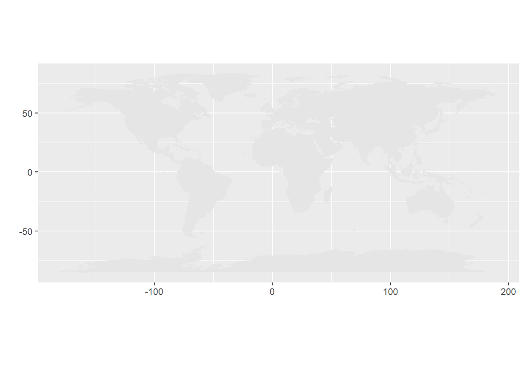

```r
library(ggplot2)
p <- ggplot() + coord_fixed() + xlab("") + ylab("")

#Add map to base plot

base_world_messy <- p + geom_polygon(data=world_map, aes(x=long, y=lat, group=group),
                                     colour="gray90", fill="gray90")
base_world_messy
```

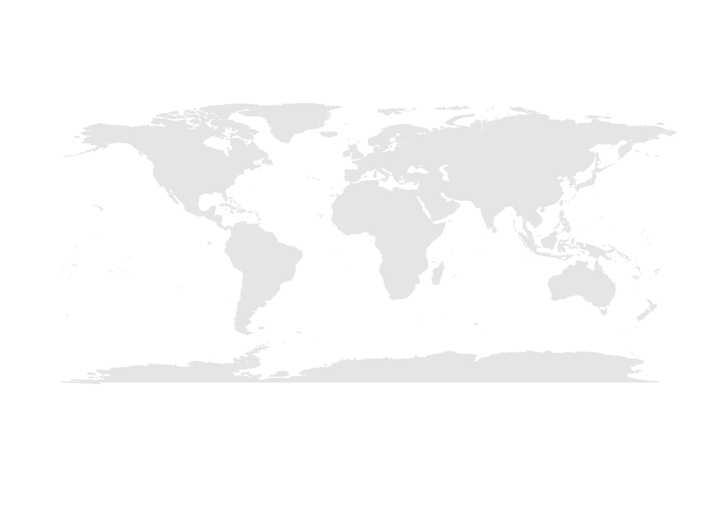

```r
df_site2$climate_zone<-factor(df_site2$climate_zone,levels=c("Tropical","Arid","Temperate","Continental"))
#Strip the map down so it looks super clean and beautiful
cleanup <-
  theme(panel.grid.major = element_blank(), panel.grid.minor = element_blank(),
        panel.background = element_rect(fill = 'white', colour = 'white'),
        axis.line = element_line(colour = "white"), legend.position="none",
        axis.ticks=element_blank(), axis.text.x=element_blank(),
        axis.text.y=element_blank())
base_world <- base_world_messy + cleanup
base_world
```

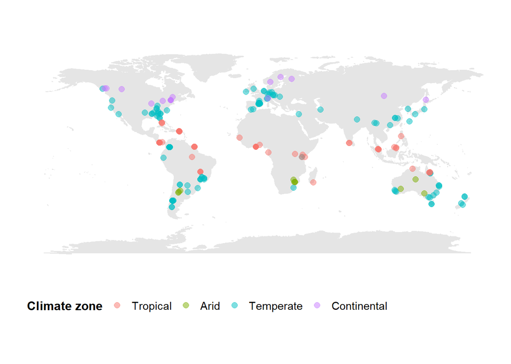

```r
p<- base_world +
  geom_point(data=df_site2,  aes(y=incubation_decimal_latitudes, x=incubation_decimal_longtitude,color=climate_zone),
             size=2.5, alpha=I(0.5))



p<- p+ theme(legend.position="bottom", legend.box = "vertical") +
  theme(legend.justification = "left")+
  labs(color="Climate zone")+
  theme(legend.title.align = -2) + theme(legend.background = element_rect(fill = "white"),
                                         legend.key = element_rect(fill = "white", color = NA))+
  guides(color=guide_legend(title.hjust=0.5))
figure1<- p+theme(legend.title = element_text(face = "bold",size = 12))+ theme(legend.text=element_text(size=11))
figure1
```

```r
path<- getwd()
ggsave(filename="Figure 1 Geographical_distribution of study sites.png", plot=figure1, device="png",
       path=path, height=5, width=7, units="in", dpi=500)
```

For us to do a weighted log response ratio meta-analysis, we need the changes in the target variable for both treatments (in our case decomposition in presence of soil fauna) and control (in our case decomposition in the absence of soil fauna) together with their standard deviations. However, some studies did not report standard deviations or other statistics that could help us estimate the standard deviation. Therefore in the next step we exclude the observations that did not include standard deviations.

```r
library(dplyr)
wood_meta_fauna$sd_exclusion<-as.numeric(wood_meta_fauna$sd_exclusion)
wood_meta_fauna$sd_inclusion<-as.numeric(wood_meta_fauna$sd_inclusion)

dim(wood_meta_fauna)
```

```
## [1] 1767   65
```

```r
wood_meta_fauna<- wood_meta_fauna %>% filter_at(vars(sd_exclusion,sd_inclusion),all_vars(!is.na(.)))
dim(wood_meta_fauna)
```

```
## [1] 1547   65
```

After excluding observations that did not report standard deviations, we now have 1547 paired observations.

Some studies have negative mass loss and this is going to be problematic when calculating the log response ratio which does not allow negative values. We therefore exclude observations with negative mass loss in the next step

```r
wood_meta_fauna <- wood_meta_fauna[wood_meta_fauna$Target_variable_loss_Exclusion >= 0, ]
dim(wood_meta_fauna)
```

```
## [1] 1452   65
```

```r
wood_meta_fauna <- wood_meta_fauna[wood_meta_fauna$Target_variable_loss_Access >= 0, ]
dim(wood_meta_fauna)
```

```
## [1] 1429   65
```

After removing the negative mass loss we have 1429 paired observations. Now we can proceed with the effect size calculation fr our meta-analysis.

## 6.2 Include standardized climatic variables (temperature and precipitation) in our dataset.

In as much as we managed to extract the temperature and precipitation data from the studies, a number of studies did not report the sites precipitation and temperature. To get the standardized values for temperature and precipitation, firstly, we extract the data from **worldclim** using **raster package** since we have the geographical coordinates of the incubation sites. *https://www.gis-blog.com/r-raster-data-acquisition/*.

```r
library(raster)
```

First we create a data frame with sites and their geographical coordinates.

```r
sites <- data.frame(site= wood_meta_fauna$Incubation_Site, long=wood_meta_fauna$incubation_decimal_longtitude, lat=wood_meta_fauna$incubation_decimal_latitudes)
```

Secondly, we now extract the precipitation and temperature data using the **getData function**. This was supposed to be automated from the worldclim website which first should enable downloading the file but since the underlying website [] runs slow or even most of time crashed, we downloaded the bioclimatic climate prior to to this. Remember that after downloading the needed .zip file, you need to unzip in your working directory and rename the unzipped file (in our case we name it wc2-5, meaning we downloaded worldclim data with 2.5 m resolution). If you downloaded the file yourself, then rember to add the “download = F”.

```r
#r2 <- raster::getData("worldclim", var="bio", res=2.5)
options(timeout = 600)
r2 <- raster::getData("worldclim", var="bio", res=2.5, download = F)
```

We need to select the required layers. We are looking for layers 1 and 12, they stand respectively for mean annual temperature (C*10) and precipitation (mm).For temperature we have to divide by 10 to get the actual temperature in degrees Celsius.

```r
r2 <- r2[[c(1, 12)]]
names(r2) <- c("Tmean", "Precip")
```

Now putting our coordinates into the format r::raster likes

```r
points <- SpatialPoints(sites[,2:3], proj4string = r2@crs)
```

Next we extracting the values for our sites coordinates using the function **extract** from raster package

```r
cc <- extract(r2, points)
```

Now bind the new temperature and precipitation values to the wood_meta_fauna data frame

```r
wood_meta_fauna <- cbind.data.frame(wood_meta_fauna, cc)
wood_meta_fauna$temperature<- wood_meta_fauna$Tmean/10
print(wood_meta_fauna)
```

## 6.3 Calculate size effects

We will use the log response ratio (LRR = log (Treatment/Control)) as our size effect (‘ROM’ in Metafor) in our case the treatment is wood decomposition in soil fauna invertebrates presence and control is wood decomposition in soil invertebrates absence. To do this, we use **escalc** function from **metafor** package.

```r
library(metafor)

lnRR <- escalc(measure = "ROM", n2i = n_sample_Exclusion, n1i = n_sample_Acess, m2i = Target_variable_loss_Exclusion,
               m1i = Target_variable_loss_Access, sd2i = sd_exclusion, sd1i = sd_inclusion, append=FALSE,data=wood_meta_fauna)
dim(lnRR)
```

```
## [1] 1429    2
```

Next after calculating the lnRR, we need to bind it to our wood_meta_fauna data frame. To do so, we will use **bind_cols** function

## 6.4 Bind lnRR to wood_meta-fauna_data

```r
wood_meta_fauna <- bind_cols(wood_meta_fauna, lnRR)
dim(wood_meta_fauna)
```

```
## [1] 1429   70
```

Two rows have mass loss equals to 0 for the WD in the absence of invertebrates. We therefore have 2 Na in the yi column after calculating the lnRR. When calculating the effect size using the random effect model the Nas are omitted and therefore we ended up with 1427 observations.

Next we can calculate the overall effect size using a random effect model.

## 6.5 Random effect model

Here we fit a random effect model with **rma** function to estimate the effect size.We use the random effect model to avoid pseudo replications and also because random effect model accounts for independence in the data. The random- effects model uses the inverse of within- studies and between- studies variance to weight the true effect sizes, and it accounts for auto correlations in observations within each study (Zhang et al., 2018). The difference between WD decomposing in the presence or absence of soil invertebrates will be considered significant if the 95% confidence interval does not overlap with zero.

```r
random_m <- rma(yi = yi, vi = vi, method = "REML", data = wood_meta_fauna)
summary(random_m)
```

```
##
## Random-Effects Model (k = 1427; tau^2 estimator: REML)
##
##     logLik    deviance         AIC         BIC        AICc
## -1429.6947   2859.3893   2863.3893   2873.9146   2863.3978
##
## tau^2 (estimated amount of total heterogeneity): 0.2926 (SE = 0.0139)
## tau (square root of estimated tau^2 value):      0.5409
## I^2 (total heterogeneity / total variability):   99.72%
## H^2 (total variability / sampling variability):  352.16
##
## Test for Heterogeneity:
## Q(df = 1426) = 585731.9656, p-val < .0001
##
## Model Results:
##
## estimate      se     zval    pval   ci.lb   ci.ub
##   0.2569  0.0165  15.5264  <.0001  0.2244  0.2893  ***
##
## ---
## Signif. codes:  0 '***' 0.001 '**' 0.01 '*' 0.05 '.' 0.1 ' ' 1
```

```r
exp(0.2569)
```

```
## [1] 1.292916
```

Since this is a ratio, if there is no difference between WD decomposing in presence of soil invertebrates and WD decomposing in the absence of soil invertebrates the ratio should be 1. Values above one imply that inclusion of soil invertebrates increase WD decomposition and values below 1 indicate that soil invertebrates inclusion reduces the rate of WD decomposition. From our results the estimate effect size of our meta-analysis is significant. This means there is a significant difference in decomposition rate when wood decomposes in the presence or absence of soil invertebrates. From the random effect model we can see that the inclusion of soil invertebrates increases wood decomposition during decomposition with around **29 percent**. Please check the multivariate analysis section to see how we got the **40 percent** reported in our manuscript.

### 6.5.1 Check for publication bias using funnel plots

To visually check for publication bias, we plot a funnel plot using the inbuilt **funnel** function in metafor. In the absence of publication bias, the studies should be evenly distributed and the funnel should be symmetrical. If the studies are skewed to the right, this would mean that more studies reported positive effect of soil invertebrates on WD decomposition implying that studies on the negative effect of soil invertebrates are often not reported. If the studies are skewed to the left then it means that more studies reported negative effect of soil invertebrates on WD decomposition and positive effects of soil invertebrates on WD decomposition is often not reported.

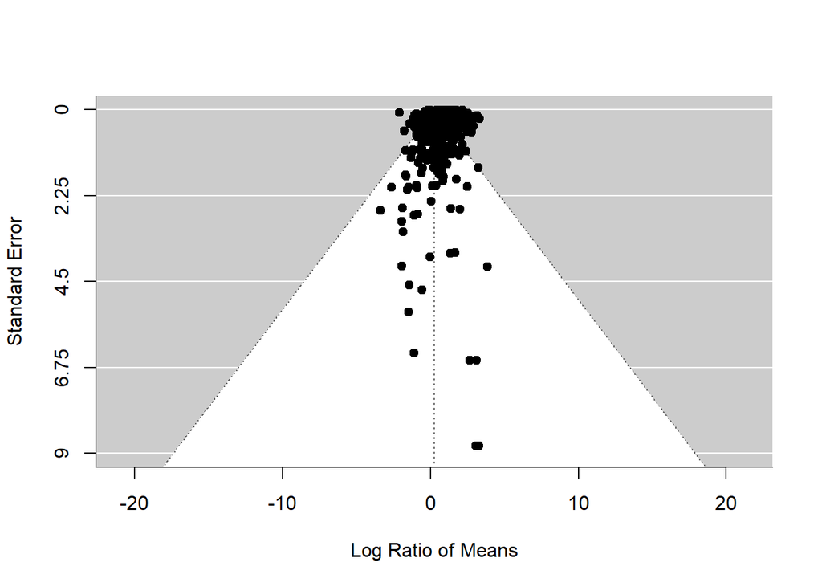

```r
funnel(random_m,ylim=c(.00001,9))
```

### 6.5.2 Plot a contour funnel plot instead

```r
png(file="Figure S4 Funnel plot.png")
funnel_plot<-funnel(wood_meta_fauna$yi, wood_meta_fauna$vi, yaxis="seinv", height=9, width=9, units="in", dpi=500,
       xlim=c(-4,4), ylim=c(.00001,30), xaxs="i", yaxs="i", las=1,
       level=c(.10, .05, .01), shade=c("white", "gray55", "gray75"),
       text.font = 3,back="gray90", ylab="Precision (1/se)", xlab= "Efffect size [ln(RR)]")
legend("topright", legend= c("0.10 < P ≤ 1.00 ", "0.05 < P ≤ 0.10", "0.05 < P ≤ 0.01", "0.00 < P ≤ 0.01"),text.font = 3, bg= "white",fill = c("white", "gray55", "gray75", "gray90"))


print(funnel_plot)
dev.off()
```

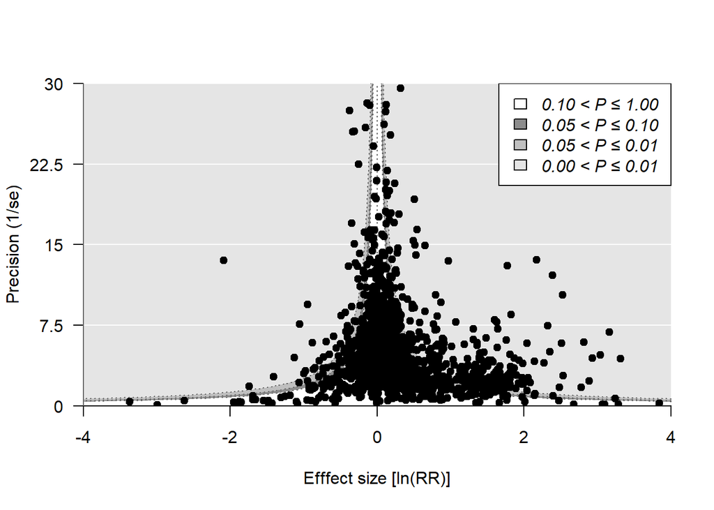

```r
funnel(wood_meta_fauna$yi, wood_meta_fauna$vi, yaxis="seinv", height=9, width=9, units="in", dpi=500,
       xlim=c(-4,4), ylim=c(.00001,30), xaxs="i", yaxs="i", las=1,
       level=c(.10, .05, .01), shade=c("white", "gray55", "gray75"),
       text.font = 3,back="gray90", ylab="Precision (1/se)", xlab= "Efffect size [ln(RR)]")
legend("topright", legend= c("0.10 < P ≤ 1.00 ", "0.05 < P ≤ 0.10", "0.05 < P ≤ 0.01", "0.00 < P ≤ 0.01"),text.font = 3, bg= "white",fill = c("white", "gray55", "gray75", "gray90"))
```

**Figure S4 Funnel plot**

There is some little asymmetry in the funnel since some studies seems to be missing on the left side of the funnel. This could be a result of having few observations on the negative effect of soil invertebrates on wood decomposition. Therefore, we need to consider if this bias can affect our conclusion by calculating the Rosenberg fail test number.

### 6.5.3 Rosenberg fail safe

To calculate the Rosenberg fail test number we use the inbuilt **fsn** function from metafor package.Rosenberg fail- safe number (Rosenberg, 2005), gives an estimate of the potential non- significant studies that need to be added to change our conclusion.

```r
fsn(yi, vi, data=wood_meta_fauna, type="Rosenberg")
```

```
##
## Fail-safe N Calculation Using the Rosenberg Approach
##
## Average Effect Size:         0.5705
## Observed Significance Level: <.0001
## Target Significance Level:   0.05
##
## Fail-safe N: 230656407
```

```r
fsn(yi, vi, data=wood_meta_fauna, type="Rosenthal")
```

```
##
## Fail-safe N Calculation Using the Rosenthal Approach
##
## Observed Significance Level: <.0001
## Target Significance Level:   0.05
##
## Fail-safe N: 11325710
```

The fail safe test number recommended threshold is **5k + 10** where k is the total number of observations (Rosenthal, 1979). In our case the number is **11325710** which is much greater than the recommended threshold. Therefore we can have confidence in our estimated effect size since its greater than the recommended threshold.

# 7 Effect of soil invertebrates on WD decomposition under different subsets of the data.

Next we want to see how the effect size varies under different subset of our data based on our hypotheses. Here we are interested to see whether soil invertebrate effect varies with; **(i) the bark status of the WD (ii) Climate zones (iii) Clades (gymnosperms/Angiosperm) (iv) Natural WD and wood blocks (v) WD diameter**

## 7.1 Effect size based on bark status

See how the effect of soil on invertebrates on wood decomposition vary with the presence or absence of bark in the wood

```r
res.m <- rma(yi, vi, data = wood_meta_fauna, subset = (Bark_status_presence_or_absent=="present"))
res.n <- rma(yi, vi, data = wood_meta_fauna, subset = (Bark_status_presence_or_absent=="absent"))
res.m
```

```
##
## Random-Effects Model (k = 769; tau^2 estimator: REML)
##
## tau^2 (estimated amount of total heterogeneity): 0.0675 (SE = 0.0059)
## tau (square root of estimated tau^2 value):      0.2598
## I^2 (total heterogeneity / total variability):   80.55%
## H^2 (total variability / sampling variability):  5.14
##
## Test for Heterogeneity:
## Q(df = 768) = 5876.0869, p-val < .0001
##
## Model Results:
##
## estimate      se    zval    pval   ci.lb   ci.ub
##   0.0968  0.0131  7.3788  <.0001  0.0711  0.1225  ***
##
## ---
## Signif. codes:  0 '***' 0.001 '**' 0.01 '*' 0.05 '.' 0.1 ' ' 1
```

```r
res.n
```

```
##
## Random-Effects Model (k = 658; tau^2 estimator: REML)
##
## tau^2 (estimated amount of total heterogeneity): 0.5037 (SE = 0.0325)
## tau (square root of estimated tau^2 value):      0.7098
## I^2 (total heterogeneity / total variability):   99.92%
## H^2 (total variability / sampling variability):  1273.05
##
## Test for Heterogeneity:
## Q(df = 657) = 569947.2499, p-val < .0001
##
## Model Results:
##
## estimate      se     zval    pval   ci.lb   ci.ub
##   0.4405  0.0302  14.5959  <.0001  0.3813  0.4996  ***
##
## ---
## Signif. codes:  0 '***' 0.001 '**' 0.01 '*' 0.05 '.' 0.1 ' ' 1
```

Visual presentation of the results using ggplot

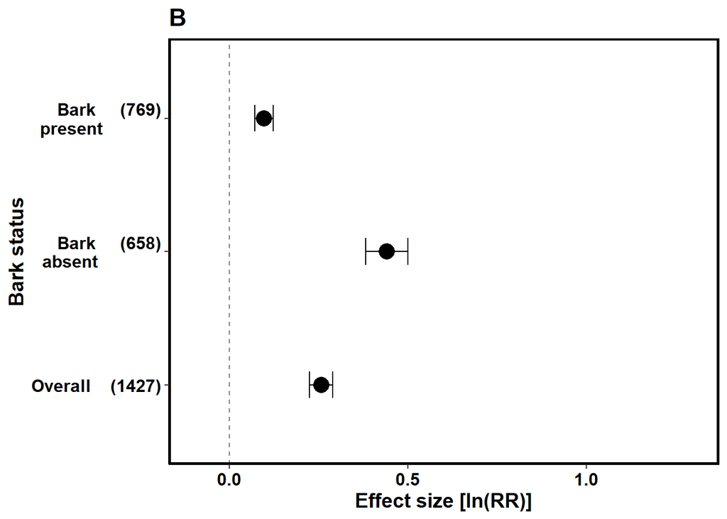

```r
dat <- data.frame(
  label = c("Bark     (769)
  present            ", "Bark     (658)
  absent             ", "Overall    (1427)"),
  point_est = c(0.0968,0.4405, 0.2569),
  lb_ci = c(0.0711,0.3813, 0.2244),
  ub_ci = c(0.1225,0.4996, 0.2893),
  group = c(1,2,3))
#require(dplyr)
#dat<- dat %>% mutate(label = factor(label),
 #             label = factor(label, levels = rev(levels(label))))
dat$label <- factor(dat$label, levels = dat$label)
plot1 <- ggplot(dat, aes(x=point_est, y=label))  +scale_x_continuous(limits = c(-0.1,1.3))+
  geom_point(size=5) + scale_y_discrete(limits = rev(levels(dat$label)))+ geom_vline(xintercept=0, color="black", linetype="dashed", alpha=.5) +
  geom_errorbarh(aes(xmin=lb_ci, xmax=ub_ci), height=.2) + theme(legend.position="none") +ggtitle("B")+
  ylab("Bark status") + xlab("Effect size [ln(RR)]") + theme(text = element_text(size = 14,face="bold"), panel.background = element_blank(),
                                                   panel.grid.major = element_blank(),
                                                   panel.grid.minor = element_blank(),
                                                   axis.line = element_line(colour = "black"),
                                                   panel.border = element_rect(colour = "black", fill=NA, size=1.5)) +  theme(axis.text = element_text(family = "palatino", colour = "black", size = (12)))
plot1
```

```r
path<- getwd()
ggsave(filename="bark status.png", plot=plot1, device="png",
       path=path, height=5, width=7, units="in", dpi=500)
```

Soil invertebrates have higher effect on wood without bark, probably because most studies have reported the effect of termites. Also studies without bark are fewer.

## 7.2 Climate zone

See how the effect of soil on invertebrates on wood decomposition vary with the climatic region

```r
resA <- rma(yi, vi, data=wood_meta_fauna, subset=climate_zone=="Tropical")
resB <- rma(yi, vi, data=wood_meta_fauna, subset=climate_zone=="Arid")
resC <- rma(yi, vi, data=wood_meta_fauna, subset=climate_zone=="Temperate")
resD <- rma(yi, vi, data=wood_meta_fauna, subset=climate_zone=="Continental")
resA
```

```
##
## Random-Effects Model (k = 420; tau^2 estimator: REML)
##
## tau^2 (estimated amount of total heterogeneity): 0.4542 (SE = 0.0371)
## tau (square root of estimated tau^2 value):      0.6740
## I^2 (total heterogeneity / total variability):   96.81%
## H^2 (total variability / sampling variability):  31.37
##
## Test for Heterogeneity:
## Q(df = 419) = 8575.4194, p-val < .0001
##
## Model Results:
##
## estimate      se     zval    pval   ci.lb   ci.ub
##   0.5602  0.0361  15.5227  <.0001  0.4894  0.6309  ***
##
## ---
## Signif. codes:  0 '***' 0.001 '**' 0.01 '*' 0.05 '.' 0.1 ' ' 1
```

```r
resB
```

```
##
## Random-Effects Model (k = 24; tau^2 estimator: REML)
##
## tau^2 (estimated amount of total heterogeneity): 1.3686 (SE = 0.4380)
## tau (square root of estimated tau^2 value):      1.1699
## I^2 (total heterogeneity / total variability):   97.78%
## H^2 (total variability / sampling variability):  45.10
##
## Test for Heterogeneity:
## Q(df = 23) = 737.3757, p-val < .0001
##
## Model Results:
##
## estimate      se    zval    pval   ci.lb   ci.ub
##   0.7977  0.2495  3.1968  0.0014  0.3086  1.2869  **
##
## ---
## Signif. codes:  0 '***' 0.001 '**' 0.01 '*' 0.05 '.' 0.1 ' ' 1
```

```r
resC
```

```
##
## Random-Effects Model (k = 872; tau^2 estimator: REML)
##
## tau^2 (estimated amount of total heterogeneity): 0.1684 (SE = 0.0111)
## tau (square root of estimated tau^2 value):      0.4103
## I^2 (total heterogeneity / total variability):   99.69%
## H^2 (total variability / sampling variability):  324.79
##
## Test for Heterogeneity:
## Q(df = 871) = 571905.3314, p-val < .0001
##
## Model Results:
##
## estimate      se    zval    pval   ci.lb   ci.ub
##   0.1242  0.0169  7.3566  <.0001  0.0911  0.1573  ***
##
## ---
## Signif. codes:  0 '***' 0.001 '**' 0.01 '*' 0.05 '.' 0.1 ' ' 1
```

```r
resD
```

```
##
## Random-Effects Model (k = 111; tau^2 estimator: REML)
##
## tau^2 (estimated amount of total heterogeneity): 0.0592 (SE = 0.0180)
## tau (square root of estimated tau^2 value):      0.2433
## I^2 (total heterogeneity / total variability):   65.02%
## H^2 (total variability / sampling variability):  2.86
##
## Test for Heterogeneity:
## Q(df = 110) = 235.9293, p-val < .0001
##
## Model Results:
##
## estimate      se    zval    pval    ci.lb   ci.ub
##   0.0199  0.0388  0.5142  0.6071  -0.0560  0.0959
##
## ---
## Signif. codes:  0 '***' 0.001 '**' 0.01 '*' 0.05 '.' 0.1 ' ' 1
```

Visual presentation of the results using ggplot

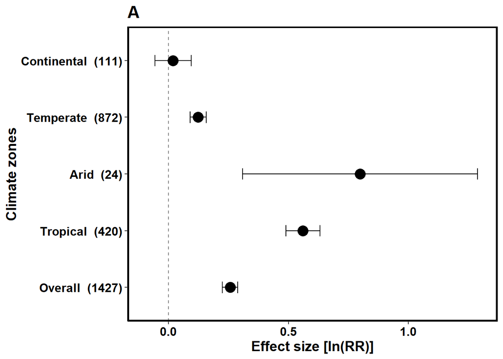

```r
dat2 <- data.frame(
  label = c("Continental  (111)","Temperate  (872)", "Arid  (24)", "Tropical  (420)","Overall  (1427)"),
  point_est = c(0.0199,0.1242, 0.7977,0.5602, 0.2569 ),
  lb_ci = c(-0.0560,0.0911,0.3086, 0.4894 , 0.2244),
  ub_ci = c( 0.0959, 0.1573,1.2869, 0.6309, 0.2893 ),
  group = c(1,2,3,4,5))
#require(dplyr)
#dat<- dat %>% mutate(label = factor(label),
 #             label = factor(label, levels = rev(levels(label))))
dat2$label <- factor(dat2$label, levels = dat2$label)
plot2 <- ggplot(dat2, aes(x=point_est, y=label))  +scale_x_continuous(limits = c(-0.1,1.3))+
  geom_point(size=4.8) + scale_y_discrete(limits = rev(levels(dat2$label)))+ geom_vline(xintercept=0, color="black", linetype="dashed", alpha=.5) +
  geom_errorbarh(aes(xmin=lb_ci, xmax=ub_ci), height=.2) + theme(legend.position="none") + ggtitle("A")+
  ylab("Climate zones") + xlab("Effect size [ln(RR)]") + theme(text = element_text(size = 14,face="bold"), panel.background = element_blank(),
                                                   panel.grid.major = element_blank(),
                                                   panel.grid.minor = element_blank(),
                                                   axis.line = element_line(colour = "black"),
                                                   panel.border = element_rect(colour = "black", fill=NA, size=1.5)) +  theme(axis.text = element_text(family = "palatino", colour = "black", size = (12)))
plot2
```

```r
path<- getwd()
ggsave(filename="climatic regions.png", plot=plot2, device="png",
       path=path, height=5, width=7, units="in", dpi=500)
```

## 7.3 Clades

```r
res.angio <- rma(yi, vi, data=wood_meta_fauna, subset=Clade=="angiosperm")
res.gymn <- rma(yi, vi, data=wood_meta_fauna, subset=Clade=="gymnosperm")
res.angio
```

```
##
## Random-Effects Model (k = 768; tau^2 estimator: REML)
##
## tau^2 (estimated amount of total heterogeneity): 0.2284 (SE = 0.0156)
## tau (square root of estimated tau^2 value):      0.4779
## I^2 (total heterogeneity / total variability):   99.70%
## H^2 (total variability / sampling variability):  335.86
##
## Test for Heterogeneity:
## Q(df = 767) = 232638.4192, p-val < .0001
##
## Model Results:
##
## estimate      se     zval    pval   ci.lb   ci.ub
##   0.2748  0.0206  13.3115  <.0001  0.2343  0.3152  ***
##
## ---
## Signif. codes:  0 '***' 0.001 '**' 0.01 '*' 0.05 '.' 0.1 ' ' 1
```

```r
res.gymn
```

```
##
## Random-Effects Model (k = 659; tau^2 estimator: REML)
##
## tau^2 (estimated amount of total heterogeneity): 0.3531 (SE = 0.0238)
## tau (square root of estimated tau^2 value):      0.5942
## I^2 (total heterogeneity / total variability):   99.59%
## H^2 (total variability / sampling variability):  243.15
##
## Test for Heterogeneity:
## Q(df = 658) = 145597.8293, p-val < .0001
##
## Model Results:
##
## estimate      se    zval    pval   ci.lb   ci.ub
##   0.2323  0.0260  8.9372  <.0001  0.1814  0.2832  ***
##
## ---
## Signif. codes:  0 '***' 0.001 '**' 0.01 '*' 0.05 '.' 0.1 ' ' 1
```

Visual presentation of the results using ggplot

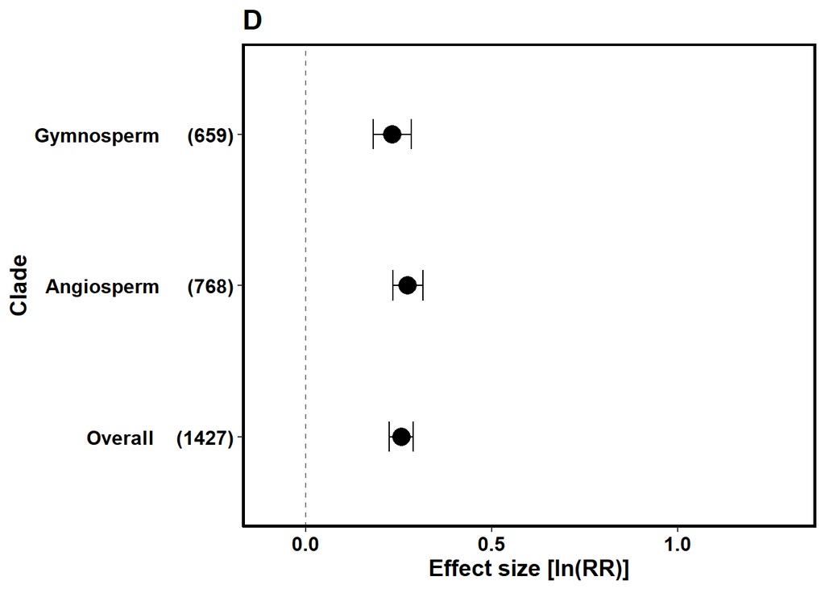

```r
dat3 <- data.frame(
  label = c("Gymnosperm     (659)", "Angiosperm     (768)", "Overall    (1427)"),
  point_est = c(0.2323, 0.2748, 0.2569),
  lb_ci = c(0.1814,0.2343, 0.2244),
  ub_ci = c(0.2832,0.3152, 0.2893),
  group = c(1,2,3))
#require(dplyr)
#dat<- dat %>% mutate(label = factor(label),
 #             label = factor(label, levels = rev(levels(label))))
dat3$label <- factor(dat3$label, levels = dat3$label)
plot3 <- ggplot(dat3, aes(x=point_est, y=label))  +scale_x_continuous(limits = c(-0.1,1.3))+
  geom_point(size=5) + scale_y_discrete(limits = rev(levels(dat3$label)))+ geom_vline(xintercept=0, color="black", linetype="dashed", alpha=.5) +
  geom_errorbarh(aes(xmin=lb_ci, xmax=ub_ci), height=.2) + theme(legend.position="none") + ggtitle("D")+
  ylab("Clade") + xlab("Effect size [ln(RR)]") + theme(text = element_text(size = 14,face="bold"), panel.background = element_blank(),
                                                   panel.grid.major = element_blank(),
                                                   panel.grid.minor = element_blank(),
                                                   axis.line = element_line(colour = "black"),
                                                   panel.border = element_rect(colour = "black", fill=NA, size=1.5)) +  theme(axis.text = element_text(family = "palatino", colour = "black", size = (12)))
plot3
```

```r
path<- getwd()
ggsave(filename="clade.png", plot=plot3, device="png",
       path=path, height=5, width=7, units="in", dpi=500)
```

The magnitude of invertebrates contribution wood decomposition is greater in Angiosperm than in gymnosperms.

## 7.4 Natural *vs.* Blocks

```r
res.block <- rma(yi, vi, data=wood_meta_fauna, subset=natural_wood_or_block=="block")
res.natural <- rma(yi, vi, data=wood_meta_fauna, subset=natural_wood_or_block=="natural")
res.block
res.natural
```

```
##
## Random-Effects Model (k = 527; tau^2 estimator: REML)
##
## tau^2 (estimated amount of total heterogeneity): 0.3899 (SE = 0.0283)
## tau (square root of estimated tau^2 value):      0.6244
## I^2 (total heterogeneity / total variability):   99.92%
## H^2 (total variability / sampling variability):  1228.77
##
## Test for Heterogeneity:
## Q(df = 526) = 568330.3730, p-val < .0001
##
## Model Results:
##
## estimate      se    zval    pval   ci.lb   ci.ub
##   0.2541  0.0298  8.5239  <.0001  0.1957  0.3125  ***
##
## ---
## Signif. codes:  0 '***' 0.001 '**' 0.01 '*' 0.05 '.' 0.1 ' ' 1
##
##
## Random-Effects Model (k = 900; tau^2 estimator: REML)
##
## tau^2 (estimated amount of total heterogeneity): 0.2153 (SE = 0.0140)
## tau (square root of estimated tau^2 value):      0.4640
## I^2 (total heterogeneity / total variability):   92.22%
## H^2 (total variability / sampling variability):  12.85
##
## Test for Heterogeneity:
## Q(df = 899) = 8166.7539, p-val < .0001
##
## Model Results:
##
## estimate      se     zval    pval   ci.lb   ci.ub
##   0.2512  0.0188  13.3618  <.0001  0.2144  0.2881  ***
##
## ---
## Signif. codes:  0 '***' 0.001 '**' 0.01 '*' 0.05 '.' 0.1 ' ' 1
```

Visual presentation of the results using ggplot

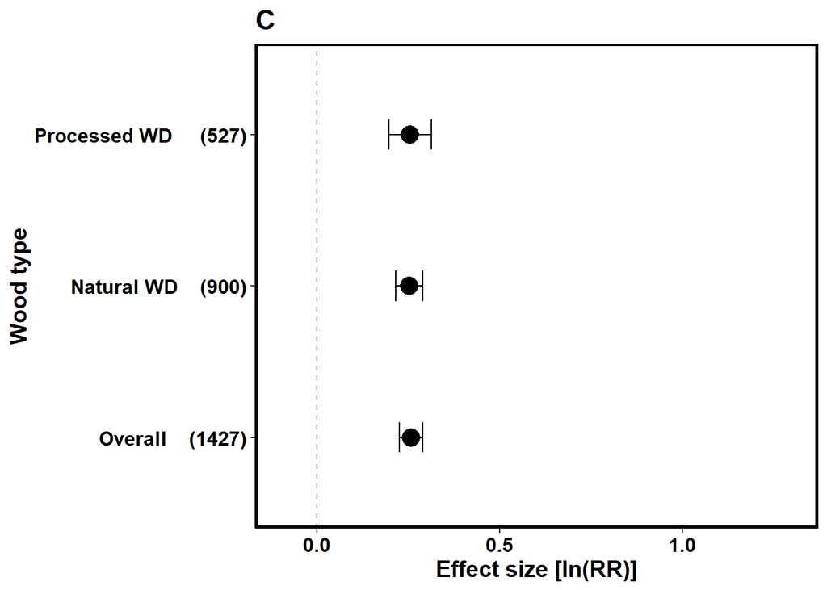

```r
dat4 <- data.frame(
  label = c("Processed WD     (527)", "Natural WD    (900)", "Overall    (1427)"),
  point_est = c( 0.2541, 0.2512, 0.2569),
  lb_ci = c(0.1957,0.2144, 0.2244),
  ub_ci = c(0.3125,0.2881, 0.2893),
  group = c(1,2,3))
#require(dplyr)
#dat<- dat %>% mutate(label = factor(label),
 #             label = factor(label, levels = rev(levels(label))))
dat4$label <- factor(dat4$label, levels = dat4$label)
plot4 <- ggplot(dat4, aes(x=point_est, y=label))  +scale_x_continuous(limits = c(-0.1,1.3))+
  geom_point(size=5) + scale_y_discrete(limits = rev(levels(dat4$label)))+ geom_vline(xintercept=0, color="black", linetype="dashed", alpha=.5) +
  geom_errorbarh(aes(xmin=lb_ci, xmax=ub_ci), height=.2) + theme(legend.position="none") + ggtitle("C")+
  ylab("Wood type") + xlab("Effect size [ln(RR)]") + theme(text = element_text(size = 14,face="bold"), panel.background = element_blank(),
                                                   panel.grid.major = element_blank(),
                                                   panel.grid.minor = element_blank(),
                                                   axis.line = element_line(colour = "black"),
                                                   panel.border = element_rect(colour = "black", fill=NA, size=1.5)) +  theme(axis.text = element_text(family = "palatino", colour = "black", size = (12)))
plot4
```

```r
path<- getwd()
ggsave(filename="block_natural.png", plot=plot4, device="png",
       path=path, height=5, width=7, units="in", dpi=500)
```

Let’s combine the figures into one with different panels

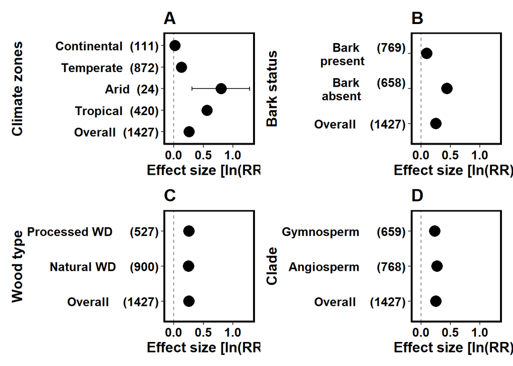

```r
library(patchwork)
fig1<- plot2 + plot1 + plot4+ plot3
fig1
```

```r
ggsave(filename="fig1.png", plot=fig1, device="png",
       path=path, height=8, width=12, units="in", dpi=500)
```

```r
res.small <- rma(yi, vi, data = wood_meta_fauna, subset = (diameter_class=="small"))
#res.medium <- rma(yi, vi, data = wood_meta_fauna, subset = (diameter_class=="medium"))
res.large <- rma(yi, vi, data = wood_meta_fauna, subset = (diameter_class=="large"))
res.small
```

```
##
## Random-Effects Model (k = 732; tau^2 estimator: REML)
##
## tau^2 (estimated amount of total heterogeneity): 0.1942 (SE = 0.0138)
## tau (square root of estimated tau^2 value):      0.4407
## I^2 (total heterogeneity / total variability):   99.78%
## H^2 (total variability / sampling variability):  445.53
##
## Test for Heterogeneity:
## Q(df = 731) = 570546.1160, p-val < .0001
##
## Model Results:
##
## estimate      se    zval    pval   ci.lb   ci.ub
##   0.1529  0.0197  7.7554  <.0001  0.1143  0.1915  ***
##
## ---
## Signif. codes:  0 '***' 0.001 '**' 0.01 '*' 0.05 '.' 0.1 ' ' 1
```

```r
#res.medium
res.large
```

```
##
## Random-Effects Model (k = 695; tau^2 estimator: REML)
##
## tau^2 (estimated amount of total heterogeneity): 0.3936 (SE = 0.0257)
## tau (square root of estimated tau^2 value):      0.6274
## I^2 (total heterogeneity / total variability):   95.04%
## H^2 (total variability / sampling variability):  20.18
##
## Test for Heterogeneity:
## Q(df = 694) = 10007.2579, p-val < .0001
##
## Model Results:
##
## estimate      se     zval    pval   ci.lb   ci.ub
##   0.3714  0.0266  13.9805  <.0001  0.3193  0.4234  ***
##
## ---
## Signif. codes:  0 '***' 0.001 '**' 0.01 '*' 0.05 '.' 0.1 ' ' 1
```

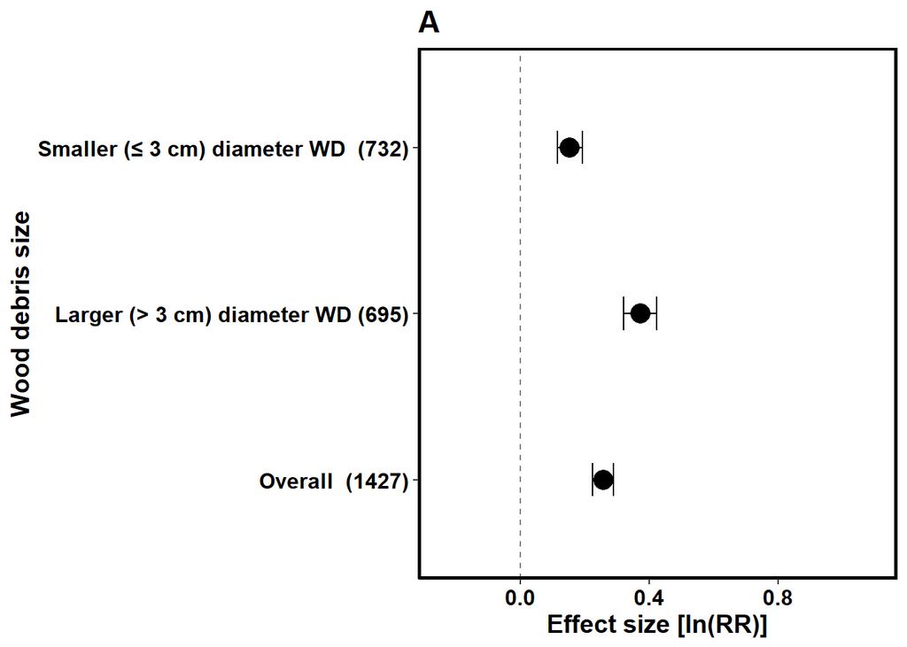

```r
dat4b <- data.frame(
  label = c("Smaller (≤ 3 cm) diameter WD  (732)", "Larger (> 3 cm) diameter WD (695)", "Overall  (1427)"),
  point_est = c(  0.1529, 0.3714,0.2569),
  lb_ci = c(0.1143,0.3193,0.2244),
  ub_ci = c(0.1915,0.4234,0.2893),
  group = c(1,2,3))

dat4b$label <- factor(dat4b$label, levels = dat4b$label)
plot4b <- ggplot(dat4b, aes(x=point_est, y=label))  + scale_x_continuous(limits = c(-0.25,1.1))+
  geom_point(size=5) + scale_y_discrete(limits = rev(levels(dat4b$label)))+ geom_vline(xintercept=0, color="black", linetype="dashed", alpha=.5) +
  geom_errorbarh(aes(xmin=lb_ci, xmax=ub_ci), height=.2) + theme(legend.position="none") + ggtitle("A")+
  ylab("Wood debris size") + xlab("Effect size [ln(RR)]") + theme(text = element_text(size = 14,face="bold"), panel.background = element_blank(),
                                                   panel.grid.major = element_blank(),
                                                   panel.grid.minor = element_blank(),
                                                   axis.line = element_line(colour = "black"),
                                                   panel.border = element_rect(colour = "black", fill=NA, size=1.5)) +  theme(axis.text = element_text(family = "palatino", colour = "black", size = (12)))
plot4b
```

```r
ggsave(filename="Figure 2 Effect of invertebrate on woody debris overall.png", plot=plot4b, device="png",
       path=path, height=5, width=7, units="in", dpi=500)
```

Create new dataframes based on the WD size.

```r
small<- wood_meta_fauna[wood_meta_fauna$diameter_class == "small", ]
large<- wood_meta_fauna[wood_meta_fauna$diameter_class == "large", ]
dim(small)
```

```
## [1] 734  70
```

```r
dim(large)
```

```
## [1] 695  70
```

```r
sm<- rma(yi = yi, vi = vi, method = "REML", data = small)
summary(sm)
```

```
##
## Random-Effects Model (k = 732; tau^2 estimator: REML)
##
##    logLik   deviance        AIC        BIC       AICc
## -628.1087  1256.2175  1260.2175  1269.4063  1260.2340
##
## tau^2 (estimated amount of total heterogeneity): 0.1942 (SE = 0.0138)
## tau (square root of estimated tau^2 value):      0.4407
## I^2 (total heterogeneity / total variability):   99.78%
## H^2 (total variability / sampling variability):  445.53
##
## Test for Heterogeneity:
## Q(df = 731) = 570546.1160, p-val < .0001
##
## Model Results:
##
## estimate      se    zval    pval   ci.lb   ci.ub
##   0.1529  0.0197  7.7554  <.0001  0.1143  0.1915  ***
##
## ---
## Signif. codes:  0 '***' 0.001 '**' 0.01 '*' 0.05 '.' 0.1 ' ' 1
```

```r
lar <- rma(yi = yi, vi = vi, method = "REML", data = large)
summary(lar)
```

```
##
## Random-Effects Model (k = 695; tau^2 estimator: REML)
##
##    logLik   deviance        AIC        BIC       AICc
## -753.4345  1506.8690  1510.8690  1519.9540  1510.8864
##
## tau^2 (estimated amount of total heterogeneity): 0.3936 (SE = 0.0257)
## tau (square root of estimated tau^2 value):      0.6274
## I^2 (total heterogeneity / total variability):   95.04%
## H^2 (total variability / sampling variability):  20.18
##
## Test for Heterogeneity:
## Q(df = 694) = 10007.2579, p-val < .0001
##
## Model Results:
##
## estimate      se     zval    pval   ci.lb   ci.ub
##   0.3714  0.0266  13.9805  <.0001  0.3193  0.4234  ***
##
## ---
## Signif. codes:  0 '***' 0.001 '**' 0.01 '*' 0.05 '.' 0.1 ' ' 1
```

```r
sm_bark<-rma(yi, vi, data = small, subset = (Bark_status_presence_or_absent=="present"))
lar_bark<-rma(yi, vi, data = large, subset = (Bark_status_presence_or_absent=="present"))
sm_bark
```

```
##
## Random-Effects Model (k = 632; tau^2 estimator: REML)
##
## tau^2 (estimated amount of total heterogeneity): 0.0659 (SE = 0.0063)
## tau (square root of estimated tau^2 value):      0.2568
## I^2 (total heterogeneity / total variability):   79.32%
## H^2 (total variability / sampling variability):  4.83
##
## Test for Heterogeneity:
## Q(df = 631) = 2523.5266, p-val < .0001
##
## Model Results:
##
## estimate      se    zval    pval   ci.lb   ci.ub
##   0.0703  0.0143  4.9085  <.0001  0.0423  0.0984  ***
##
## ---
## Signif. codes:  0 '***' 0.001 '**' 0.01 '*' 0.05 '.' 0.1 ' ' 1
```

```r
lar_bark
```

```
##
## Random-Effects Model (k = 137; tau^2 estimator: REML)
##
## tau^2 (estimated amount of total heterogeneity): 0.0599 (SE = 0.0128)
## tau (square root of estimated tau^2 value):      0.2447
## I^2 (total heterogeneity / total variability):   81.20%
## H^2 (total variability / sampling variability):  5.32
##
## Test for Heterogeneity:
## Q(df = 136) = 2603.0417, p-val < .0001
##
## Model Results:
##
## estimate      se    zval    pval   ci.lb   ci.ub
##   0.2209  0.0301  7.3485  <.0001  0.1620  0.2798  ***
##
## ---
## Signif. codes:  0 '***' 0.001 '**' 0.01 '*' 0.05 '.' 0.1 ' ' 1
```

```r
sm_bark_none<-rma(yi, vi, data = small, subset = (Bark_status_presence_or_absent=="absent"))
lar_bark_none<-rma(yi, vi, data = large, subset = (Bark_status_presence_or_absent=="absent"))

sm_bark_none
```

```
##
## Random-Effects Model (k = 100; tau^2 estimator: REML)
##
## tau^2 (estimated amount of total heterogeneity): 0.5696 (SE = 0.0936)
## tau (square root of estimated tau^2 value):      0.7547
## I^2 (total heterogeneity / total variability):   99.99%
## H^2 (total variability / sampling variability):  9392.02
##
## Test for Heterogeneity:
## Q(df = 99) = 557606.7421, p-val < .0001
##
## Model Results:
##
## estimate      se    zval    pval   ci.lb   ci.ub
##   0.6069  0.0828  7.3326  <.0001  0.4447  0.7692  ***
##
## ---
## Signif. codes:  0 '***' 0.001 '**' 0.01 '*' 0.05 '.' 0.1 ' ' 1
```

```r
lar_bark_none
```

```
##
## Random-Effects Model (k = 558; tau^2 estimator: REML)
##
## tau^2 (estimated amount of total heterogeneity): 0.4830 (SE = 0.0340)
## tau (square root of estimated tau^2 value):      0.6950
## I^2 (total heterogeneity / total variability):   95.28%
## H^2 (total variability / sampling variability):  21.17
##
## Test for Heterogeneity:
## Q(df = 557) = 6977.3880, p-val < .0001
##
## Model Results:
##
## estimate      se     zval    pval   ci.lb   ci.ub
##   0.4101  0.0321  12.7712  <.0001  0.3472  0.4730  ***
##
## ---
## Signif. codes:  0 '***' 0.001 '**' 0.01 '*' 0.05 '.' 0.1 ' ' 1
```

```r
dat9b <- data.frame(
  label = c("Smaller (<= 3cm) diameter WD (732)","Bark present (632)", "Bark  absent (100) ",
           "Larger (> 3cm) diameter WD (695)","Bark  present (137)","Bark  absent (558) "),
  point_est = c(0.1529, 0.0703, 0.6069, 0.3714,0.2209, 0.4101 ),
  lb_ci = c(0.1143, 0.0423,0.4447,0.3193,0.1620,0.3472),
  ub_ci = c( 0.1915,0.0984,0.7692,0.4234,0.2798,0.4730),
  group = c(1,2,3,1,2,3),
  region= c(1,1,1,2,2,2)
)
dat9b$label <- factor(dat9b$label, levels = dat9b$label)
as.factor(dat9b$group)
```

```
## [1] 1 2 3 1 2 3
## Levels: 1 2 3
```

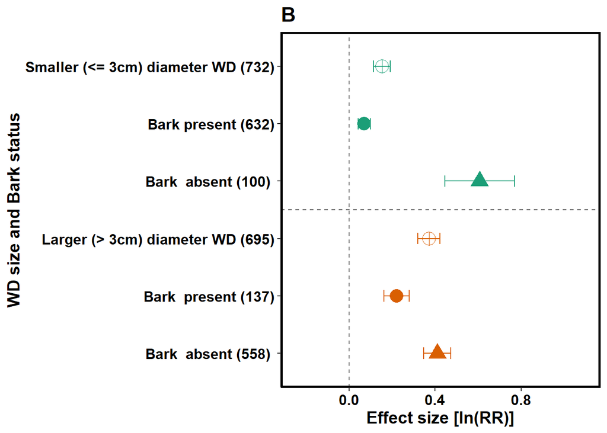

```r
plot9b <- ggplot(dat9b, aes(x=point_est, y=label, shape=as.factor(group),color=as.factor(region))) +scale_shape_manual(values = c(10, 16, 17))+
  theme(legend.position="none") +scale_color_brewer(palette="Dark2")+scale_x_continuous(limits = c(-0.25,1.1))+
  geom_point(size=5) + scale_y_discrete(limits = rev(levels(dat9b$label))) + geom_vline(xintercept=0, color="black", linetype="dashed", alpha=.5) +
  geom_hline(yintercept = c(3.5),color="black", linetype="dashed", alpha=.7)+
  geom_errorbarh(aes(xmin=lb_ci, xmax=ub_ci), height=.2) +
  ggtitle("B")+
  ylab("WD size and Bark status") + xlab("Effect size [ln(RR)]") + theme(text = element_text(size = 14,face="bold"), panel.background = element_blank(),
                                                   panel.grid.major = element_blank(),
                                                   panel.grid.minor = element_blank(),
                                                   axis.line = element_line(colour = "black"),
                                                   panel.border = element_rect(colour = "black", fill=NA, size=1.5)) +  theme(axis.text = element_text(family = "palatino", colour = "black", size = (12)))
plot9b
```

```r
sm_trp<-rma(yi, vi, data = small, subset = (climate_zone=="Tropical"))
lar_trp<-rma(yi, vi, data = large, subset = (climate_zone=="Tropical"))
sm_trp
```

```
##
## Random-Effects Model (k = 175; tau^2 estimator: REML)
##
## tau^2 (estimated amount of total heterogeneity): 0.0960 (SE = 0.0142)
## tau (square root of estimated tau^2 value):      0.3099
## I^2 (total heterogeneity / total variability):   90.36%
## H^2 (total variability / sampling variability):  10.38
##
## Test for Heterogeneity:
## Q(df = 174) = 1430.0806, p-val < .0001
##
## Model Results:
##
## estimate      se    zval    pval   ci.lb   ci.ub
##   0.1732  0.0285  6.0764  <.0001  0.1173  0.2290  ***
##
## ---
## Signif. codes:  0 '***' 0.001 '**' 0.01 '*' 0.05 '.' 0.1 ' ' 1
```

```r
lar_trp
```

```
##
## Random-Effects Model (k = 245; tau^2 estimator: REML)
##
## tau^2 (estimated amount of total heterogeneity): 0.5623 (SE = 0.0601)
## tau (square root of estimated tau^2 value):      0.7498
## I^2 (total heterogeneity / total variability):   96.00%
## H^2 (total variability / sampling variability):  24.98
##
## Test for Heterogeneity:
## Q(df = 244) = 6011.0523, p-val < .0001
##
## Model Results:
##
## estimate      se     zval    pval   ci.lb   ci.ub
##   0.8559  0.0524  16.3425  <.0001  0.7532  0.9585  ***
##
## ---
## Signif. codes:  0 '***' 0.001 '**' 0.01 '*' 0.05 '.' 0.1 ' ' 1
```

```r
#sm_ard<-rma(yi, vi, data = small, subset = (climate_zone=="Arid"))
lar_ard<-rma(yi, vi, data = large, subset = (climate_zone=="Arid"))
#sm_ard
lar_ard
```

```
##
## Random-Effects Model (k = 24; tau^2 estimator: REML)
##
## tau^2 (estimated amount of total heterogeneity): 1.3686 (SE = 0.4380)
## tau (square root of estimated tau^2 value):      1.1699
## I^2 (total heterogeneity / total variability):   97.78%
## H^2 (total variability / sampling variability):  45.10
##
## Test for Heterogeneity:
## Q(df = 23) = 737.3757, p-val < .0001
##
## Model Results:
##
## estimate      se    zval    pval   ci.lb   ci.ub
##   0.7977  0.2495  3.1968  0.0014  0.3086  1.2869  **
##
## ---
## Signif. codes:  0 '***' 0.001 '**' 0.01 '*' 0.05 '.' 0.1 ' ' 1
```

```r
sm_temp<-rma(yi, vi, data = small, subset = (climate_zone=="Temperate"))
lar_temp<-rma(yi, vi, data = large, subset = (climate_zone=="Temperate"))
sm_temp
```

```
##
## Random-Effects Model (k = 459; tau^2 estimator: REML)
##
## tau^2 (estimated amount of total heterogeneity): 0.2414 (SE = 0.0209)
## tau (square root of estimated tau^2 value):      0.4913
## I^2 (total heterogeneity / total variability):   99.89%
## H^2 (total variability / sampling variability):  870.85
##
## Test for Heterogeneity:
## Q(df = 458) = 563711.7319, p-val < .0001
##
## Model Results:
##
## estimate      se    zval    pval   ci.lb   ci.ub
##   0.1638  0.0271  6.0379  <.0001  0.1107  0.2170  ***
##
## ---
## Signif. codes:  0 '***' 0.001 '**' 0.01 '*' 0.05 '.' 0.1 ' ' 1
```

```r
lar_temp
```

```
##
## Random-Effects Model (k = 413; tau^2 estimator: REML)
##
## tau^2 (estimated amount of total heterogeneity): 0.0718 (SE = 0.0083)
## tau (square root of estimated tau^2 value):      0.2680
## I^2 (total heterogeneity / total variability):   78.59%
## H^2 (total variability / sampling variability):  4.67
##
## Test for Heterogeneity:
## Q(df = 412) = 1365.7953, p-val < .0001
##
## Model Results:
##
## estimate      se    zval    pval   ci.lb   ci.ub
##   0.0739  0.0178  4.1424  <.0001  0.0389  0.1089  ***
##
## ---
## Signif. codes:  0 '***' 0.001 '**' 0.01 '*' 0.05 '.' 0.1 ' ' 1
```

```r
sm_cont<-rma(yi, vi, data = small, subset = (climate_zone=="Continental"))
lar_cont<-rma(yi, vi, data = large, subset = (climate_zone=="Continental"))
sm_cont
```

```
##
## Random-Effects Model (k = 98; tau^2 estimator: REML)
##
## tau^2 (estimated amount of total heterogeneity): 0.0908 (SE = 0.0272)
## tau (square root of estimated tau^2 value):      0.3013
## I^2 (total heterogeneity / total variability):   71.71%
## H^2 (total variability / sampling variability):  3.53
##
## Test for Heterogeneity:
## Q(df = 97) = 220.0614, p-val < .0001
##
## Model Results:
##
## estimate      se    zval    pval    ci.lb   ci.ub
##   0.0287  0.0487  0.5892  0.5558  -0.0667  0.1241
##
## ---
## Signif. codes:  0 '***' 0.001 '**' 0.01 '*' 0.05 '.' 0.1 ' ' 1
```

```r
lar_cont
```

```
##
## Random-Effects Model (k = 13; tau^2 estimator: REML)
##
## tau^2 (estimated amount of total heterogeneity): 0 (SE = 0.0052)
## tau (square root of estimated tau^2 value):      0
## I^2 (total heterogeneity / total variability):   0.00%
## H^2 (total variability / sampling variability):  1.00
##
## Test for Heterogeneity:
## Q(df = 12) = 6.6408, p-val = 0.8804
##
## Model Results:
##
## estimate      se     zval    pval    ci.lb   ci.ub
##  -0.0628  0.0374  -1.6800  0.0930  -0.1362  0.0105  .
##
## ---
## Signif. codes:  0 '***' 0.001 '**' 0.01 '*' 0.05 '.' 0.1 ' ' 1
```

Plot wood debris size across different Climate zone

```r
dat10b <- data.frame(
  label = c("Smaller (≤ 3 cm) diameter WD (732)","Boreal (93)", "Temperate (136) ","Subtropic (312)","Tropics (191) ",
           "Larger  (> 3 cm) diameter WD (695)","Temperate (146)","Subtropic (215)","Tropics (320) "),
  point_est = c(0.1529,0.0463,0.0097,0.2045,0.1714,0.3714, -0.0488,0.2205,0.6979),
  lb_ci = c(0.1143,-0.0196, -0.0632,0.1364, 0.1175,0.3193,-0.0892,0.1621,0.6061),
  ub_ci = c( 0.1915,0.1121,0.0827,0.2726,0.2253,0.4234,-0.0083,0.2790,0.7896),
  group = c(1,2,3,4,5,1,3,4,5),
  region= c(1,1,1,1,1,2,2,2,2)
)
dat10b$label <- factor(dat10b$label, levels = dat10b$label)
as.factor(dat9b$group)
```

```
## [1] 1 2 3 1 2 3
## Levels: 1 2 3
```

[figure not shown]

```r
plot10b <- ggplot(dat10b, aes(x=point_est, y=label, shape=as.factor(group),color=as.factor(region))) +scale_shape_manual(values = c(10, 16, 17, 22, 15))+
  theme(legend.position="none") +scale_color_brewer(palette="Dark2")+scale_x_continuous(limits = c(-0.25,1.1))+
  geom_point(size=5) + scale_y_discrete(limits = rev(levels(dat10b$label))) + geom_vline(xintercept=0, color="black", linetype="dashed", alpha=.5) +
  geom_hline(yintercept = c(4.5),color="black", linetype="dashed", alpha=.7)+
  geom_errorbarh(aes(xmin=lb_ci, xmax=ub_ci), height=.2) +
  ggtitle("A")+
  ylab("WD size and climatic regions") + xlab("Effect size [ln(RR)]") + theme(text = element_text(size = 14,face="bold"), panel.background = element_blank(),
                                                   panel.grid.major = element_blank(),
                                                   panel.grid.minor = element_blank(),
                                                   axis.line = element_line(colour = "black"),
                                                   panel.border = element_rect(colour = "black", fill=NA, size=1.5)) +  theme(axis.text = element_text(family = "palatino", colour = "black", size = (12)))
plot10b
```

Natural WD *vs.* processed WD

```r
sm_block<-rma(yi, vi, data = small, subset = (natural_wood_or_block=="block"))
lar_block<-rma(yi, vi, data = large, subset = (natural_wood_or_block=="block"))
sm_block
```

```
##
## Random-Effects Model (k = 91; tau^2 estimator: REML)
##
## tau^2 (estimated amount of total heterogeneity): 0.5597 (SE = 0.0979)
## tau (square root of estimated tau^2 value):      0.7481
## I^2 (total heterogeneity / total variability):   99.99%
## H^2 (total variability / sampling variability):  10142.86
##
## Test for Heterogeneity:
## Q(df = 90) = 557033.4647, p-val < .0001
##
## Model Results:
##
## estimate      se    zval    pval   ci.lb   ci.ub
##   0.6960  0.0868  8.0162  <.0001  0.5258  0.8662  ***
##
## ---
## Signif. codes:  0 '***' 0.001 '**' 0.01 '*' 0.05 '.' 0.1 ' ' 1
```

```r
lar_block
```

```
##
## Random-Effects Model (k = 436; tau^2 estimator: REML)
##
## tau^2 (estimated amount of total heterogeneity): 0.3014 (SE = 0.0247)
## tau (square root of estimated tau^2 value):      0.5490
## I^2 (total heterogeneity / total variability):   93.84%
## H^2 (total variability / sampling variability):  16.24
##
## Test for Heterogeneity:
## Q(df = 435) = 4601.1882, p-val < .0001
##
## Model Results:
##
## estimate      se    zval    pval   ci.lb   ci.ub
##   0.1653  0.0292  5.6678  <.0001  0.1082  0.2225  ***
##
## ---
## Signif. codes:  0 '***' 0.001 '**' 0.01 '*' 0.05 '.' 0.1 ' ' 1
```

```r
sm_natural<-rma(yi, vi, data = small, subset = (natural_wood_or_block=="natural"))
lar_natural<-rma(yi, vi, data = large, subset = (natural_wood_or_block=="natural"))
sm_natural
```

```
##
## Random-Effects Model (k = 641; tau^2 estimator: REML)
##
## tau^2 (estimated amount of total heterogeneity): 0.0652 (SE = 0.0062)
## tau (square root of estimated tau^2 value):      0.2553
## I^2 (total heterogeneity / total variability):   79.41%
## H^2 (total variability / sampling variability):  4.86
##
## Test for Heterogeneity:
## Q(df = 640) = 2565.9770, p-val < .0001
##
## Model Results:
##
## estimate      se    zval    pval   ci.lb   ci.ub
##   0.0655  0.0141  4.6430  <.0001  0.0379  0.0932  ***
##
## ---
## Signif. codes:  0 '***' 0.001 '**' 0.01 '*' 0.05 '.' 0.1 ' ' 1
```

```r
lar_natural
```

```
##
## Random-Effects Model (k = 259; tau^2 estimator: REML)
##
## tau^2 (estimated amount of total heterogeneity): 0.3698 (SE = 0.0432)
## tau (square root of estimated tau^2 value):      0.6081
## I^2 (total heterogeneity / total variability):   94.07%
## H^2 (total variability / sampling variability):  16.87
##
## Test for Heterogeneity:
## Q(df = 258) = 4033.6240, p-val < .0001
##
## Model Results:
##
## estimate      se     zval    pval   ci.lb   ci.ub
##   0.7644  0.0444  17.2098  <.0001  0.6774  0.8515  ***
##
## ---
## Signif. codes:  0 '***' 0.001 '**' 0.01 '*' 0.05 '.' 0.1 ' ' 1
```

```r
dat11b <- data.frame(
  label = c("Smaller (≤ 3 cm) diameter WD (732)","Processed WD (91)", "Natural WD (641) ",
           "Larger (> 3 cm) diameter WD (695)","Processed WD (436)","Natural WD (259) "),
  point_est = c(0.1529,0.6960,0.0655, 0.3714,0.1653,0.7644 ),
  lb_ci = c(0.1143,0.5258,0.0379,0.3193,0.1082,0.6774 ),
  ub_ci = c( 0.1915,0.8662,.0932,0.4234,0.2225,0.8515),
  group = c(1,2,3,1,2,3),
  region= c(1,1,1,2,2,2)
)
dat11b$label <- factor(dat11b$label, levels = dat11b$label)
as.factor(dat9b$group)
```

```
## [1] 1 2 3 1 2 3
## Levels: 1 2 3
```

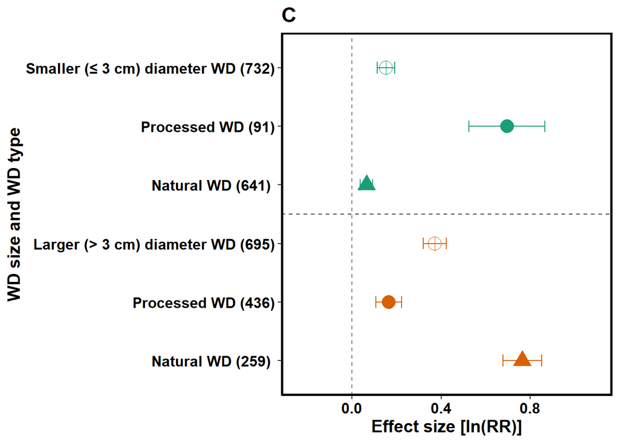

```r
plot11b <- ggplot(dat11b, aes(x=point_est, y=label, shape=as.factor(group),color=as.factor(region))) +scale_shape_manual(values = c(10, 16, 17))+
  theme(legend.position="none") +scale_color_brewer(palette="Dark2")+scale_x_continuous(limits = c(-0.25,1.1))+
  geom_point(size=5) + scale_y_discrete(limits = rev(levels(dat11b$label))) + geom_vline(xintercept=0, color="black", linetype="dashed", alpha=.5) +
  geom_hline(yintercept = c(3.5),color="black", linetype="dashed", alpha=.7)+
  geom_errorbarh(aes(xmin=lb_ci, xmax=ub_ci), height=.2) +
  ggtitle("C")+
  ylab("WD size and WD type") + xlab("Effect size [ln(RR)]") + theme(text = element_text(size = 14,face="bold"), panel.background = element_blank(),
                                                   panel.grid.major = element_blank(),
                                                   panel.grid.minor = element_blank(),
                                                   axis.line = element_line(colour = "black"),
                                                   panel.border = element_rect(colour = "black", fill=NA, size=1.5)) +  theme(axis.text = element_text(family = "palatino", colour = "black", size = (12)))
plot11b
```

```r
sm_gymn<-rma(yi, vi, data = small, subset = (Clade=="gymnosperm"))
lar_gymn<-rma(yi, vi, data = large, subset = (Clade=="gymnosperm"))
sm_gymn
```

```
##
## Random-Effects Model (k = 139; tau^2 estimator: REML)
##
## tau^2 (estimated amount of total heterogeneity): 0.5285 (SE = 0.0770)
## tau (square root of estimated tau^2 value):      0.7270
## I^2 (total heterogeneity / total variability):   99.94%
## H^2 (total variability / sampling variability):  1614.34
##
## Test for Heterogeneity:
## Q(df = 138) = 112357.6526, p-val < .0001
##
## Model Results:
##
## estimate      se    zval    pval   ci.lb   ci.ub
##   0.3444  0.0696  4.9451  <.0001  0.2079  0.4809  ***
##
## ---
## Signif. codes:  0 '***' 0.001 '**' 0.01 '*' 0.05 '.' 0.1 ' ' 1
```

```r
lar_gymn
```

```
##
## Random-Effects Model (k = 520; tau^2 estimator: REML)
##
## tau^2 (estimated amount of total heterogeneity): 0.2952 (SE = 0.0227)
## tau (square root of estimated tau^2 value):      0.5433
## I^2 (total heterogeneity / total variability):   93.27%
## H^2 (total variability / sampling variability):  14.87
##
## Test for Heterogeneity:
## Q(df = 519) = 4863.9303, p-val < .0001
##
## Model Results:
##
## estimate      se    zval    pval   ci.lb   ci.ub
##   0.2006  0.0269  7.4574  <.0001  0.1479  0.2534  ***
##
## ---
## Signif. codes:  0 '***' 0.001 '**' 0.01 '*' 0.05 '.' 0.1 ' ' 1
```

```r
sm_angio<-rma(yi, vi, data = small, subset = (Clade=="angiosperm"))
lar_angio<-rma(yi, vi, data = large, subset = (Clade=="angiosperm"))
sm_angio
```

```
##
## Random-Effects Model (k = 593; tau^2 estimator: REML)
##
## tau^2 (estimated amount of total heterogeneity): 0.0819 (SE = 0.0075)
## tau (square root of estimated tau^2 value):      0.2862
## I^2 (total heterogeneity / total variability):   99.35%
## H^2 (total variability / sampling variability):  155.03
##
## Test for Heterogeneity:
## Q(df = 592) = 228781.8801, p-val < .0001
##
## Model Results:
##
## estimate      se    zval    pval   ci.lb   ci.ub
##   0.1021  0.0157  6.4916  <.0001  0.0713  0.1329  ***
##
## ---
## Signif. codes:  0 '***' 0.001 '**' 0.01 '*' 0.05 '.' 0.1 ' ' 1
```

```r
lar_angio
```

```
##
## Random-Effects Model (k = 175; tau^2 estimator: REML)
##
## tau^2 (estimated amount of total heterogeneity): 0.3667 (SE = 0.0515)
## tau (square root of estimated tau^2 value):      0.6056
## I^2 (total heterogeneity / total variability):   94.81%
## H^2 (total variability / sampling variability):  19.28
##
## Test for Heterogeneity:
## Q(df = 174) = 3556.7089, p-val < .0001
##
## Model Results:
##
## estimate      se     zval    pval   ci.lb   ci.ub
##   0.9095  0.0532  17.0856  <.0001  0.8052  1.0138  ***
##
## ---
## Signif. codes:  0 '***' 0.001 '**' 0.01 '*' 0.05 '.' 0.1 ' ' 1
```

```r
dat12b <- data.frame(
  label = c("Smaller ( ≤ 3 cm) diameter WD (732)","Gymnosperm (139)", "Angiosperm (593) ",
           "Larger (> 3 cm) diameter WD  (695)","Gymnosperm (520)","Angiosperm (175) "),
  point_est = c(0.1529, 0.3444,0.1021, 0.3714, 0.2006,0.9095),
  lb_ci = c(0.1143, 0.2079,0.0713,0.3193,0.1479,0.8052),
  ub_ci = c( 0.1915,0.4809,0.1329,0.4234,0.2534, 1.0138 ),
  group = c(1,2,3,1,2,3),
  region= c(1,1,1,2,2,2)
)
dat12b$label <- factor(dat12b$label, levels = dat12b$label)
as.factor(dat9b$group)
```

```
## [1] 1 2 3 1 2 3
## Levels: 1 2 3
```

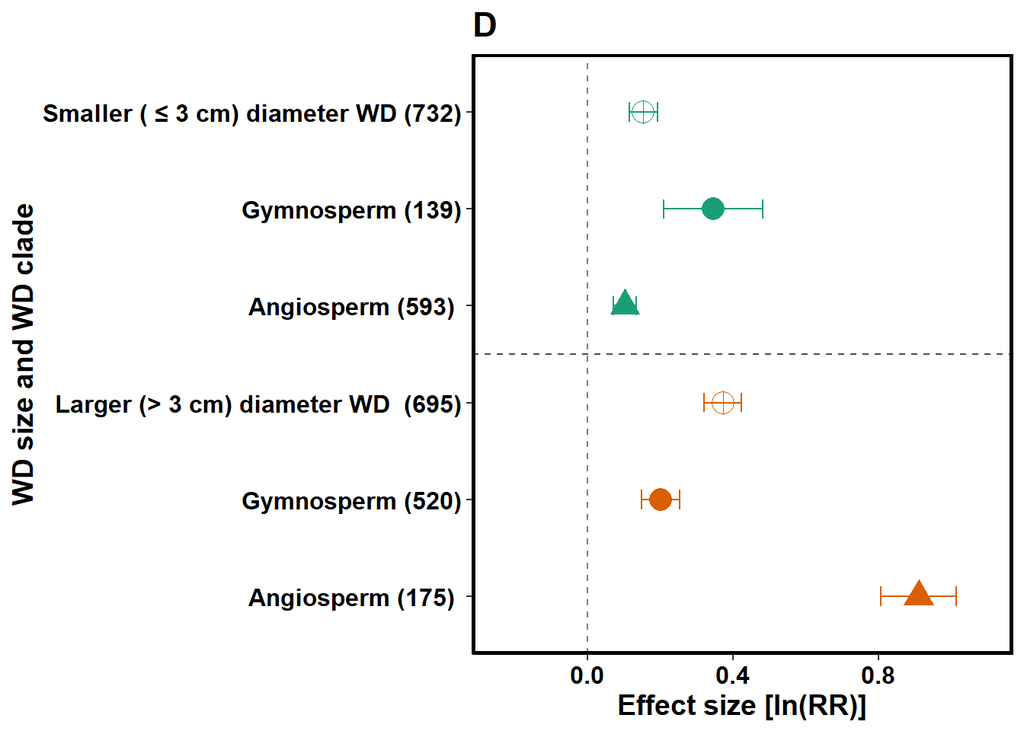

```r
plot12b <- ggplot(dat12b, aes(x=point_est, y=label, shape=as.factor(group),color=as.factor(region))) +scale_shape_manual(values = c(10, 16, 17))+
  theme(legend.position="none") +scale_color_brewer(palette="Dark2")+scale_x_continuous(limits = c(-0.25,1.1))+
  geom_point(size=5) + scale_y_discrete(limits = rev(levels(dat12b$label))) + geom_vline(xintercept=0, color="black", linetype="dashed", alpha=.5) +
  geom_hline(yintercept = c(3.5),color="black", linetype="dashed", alpha=.7)+
  geom_errorbarh(aes(xmin=lb_ci, xmax=ub_ci), height=.2) +
  ggtitle("D")+
  ylab("WD size and WD clade") + xlab("Effect size [ln(RR)]") + theme(text = element_text(size = 14,face="bold"), panel.background = element_blank(),
                                                   panel.grid.major = element_blank(),
                                                   panel.grid.minor = element_blank(),
                                                   axis.line = element_line(colour = "black"),
                                                   panel.border = element_rect(colour = "black", fill=NA, size=1.5)) +  theme(axis.text = element_text(family = "palatino", colour = "black", size = (12)))
plot12b
```

[figure not shown]

```r
library(patchwork)
fig_diameter<-  plot4b +plot9b+plot11b+plot12b
fig_diameter
```

```r
ggsave(filename="Figure 3 diameter.png", plot=fig_diameter, device="png",
       path=path, height=8, width=12, units="in", dpi=500)
```

```r
tropical<- wood_meta_fauna[wood_meta_fauna$climate_zone == "Tropical", ]
arid<- wood_meta_fauna[wood_meta_fauna$climate_zone == "Arid", ]
temperate<- wood_meta_fauna[wood_meta_fauna$climate_zone == "Temperate", ]
continental<- wood_meta_fauna[wood_meta_fauna$climate_zone == "Continental", ]
dim(tropical)
```

```
## [1] 422  70
```

```r
dim(arid)
```

```
## [1] 24 70
```

```r
dim(temperate)
```

```
## [1] 872  70
```

```r
dim(continental)
```

```
## [1] 111  70
```

```r
#tropical regions
trop <- rma(yi = yi, vi = vi, method = "REML", data = tropical)
summary(trop)
```

```
##
## Random-Effects Model (k = 420; tau^2 estimator: REML)
##
##    logLik   deviance        AIC        BIC       AICc
## -477.7081   955.4161   959.4161   967.4919   959.4450
##
## tau^2 (estimated amount of total heterogeneity): 0.4542 (SE = 0.0371)
## tau (square root of estimated tau^2 value):      0.6740
## I^2 (total heterogeneity / total variability):   96.81%
## H^2 (total variability / sampling variability):  31.37
##
## Test for Heterogeneity:
## Q(df = 419) = 8575.4194, p-val < .0001
##
## Model Results:
##
## estimate      se     zval    pval   ci.lb   ci.ub
##   0.5602  0.0361  15.5227  <.0001  0.4894  0.6309  ***
##
## ---
## Signif. codes:  0 '***' 0.001 '**' 0.01 '*' 0.05 '.' 0.1 ' ' 1
```

```r
#arid regions
ard <- rma(yi = yi, vi = vi, method = "REML", data = arid)
summary(ard)
```

```
##
## Random-Effects Model (k = 24; tau^2 estimator: REML)
##
##   logLik  deviance       AIC       BIC      AICc
## -37.3234   74.6468   78.6468   80.9178   79.2468
##
## tau^2 (estimated amount of total heterogeneity): 1.3686 (SE = 0.4380)
## tau (square root of estimated tau^2 value):      1.1699
## I^2 (total heterogeneity / total variability):   97.78%
## H^2 (total variability / sampling variability):  45.10
##
## Test for Heterogeneity:
## Q(df = 23) = 737.3757, p-val < .0001
##
## Model Results:
##
## estimate      se    zval    pval   ci.lb   ci.ub
##   0.7977  0.2495  3.1968  0.0014  0.3086  1.2869  **
##
## ---
## Signif. codes:  0 '***' 0.001 '**' 0.01 '*' 0.05 '.' 0.1 ' ' 1
```

```r
#temperate region
temp <- rma(yi = yi, vi = vi, method = "REML", data = temperate)
summary(temp)
```

```
##
## Random-Effects Model (k = 872; tau^2 estimator: REML)
##
##    logLik   deviance        AIC        BIC       AICc
## -656.3163  1312.6327  1316.6327  1326.1719  1316.6465
##
## tau^2 (estimated amount of total heterogeneity): 0.1684 (SE = 0.0111)
## tau (square root of estimated tau^2 value):      0.4103
## I^2 (total heterogeneity / total variability):   99.69%
## H^2 (total variability / sampling variability):  324.79
##
## Test for Heterogeneity:
## Q(df = 871) = 571905.3314, p-val < .0001
##
## Model Results:
##
## estimate      se    zval    pval   ci.lb   ci.ub
##   0.1242  0.0169  7.3566  <.0001  0.0911  0.1573  ***
##
## ---
## Signif. codes:  0 '***' 0.001 '**' 0.01 '*' 0.05 '.' 0.1 ' ' 1
```

```r
#Continental
cont <- rma(yi = yi, vi = vi, method = "REML", data = continental)
summary(cont)
```

```
##
## Random-Effects Model (k = 111; tau^2 estimator: REML)
##
##   logLik  deviance       AIC       BIC      AICc
## -95.6101  191.2201  195.2201  200.6211  195.3323
##
## tau^2 (estimated amount of total heterogeneity): 0.0592 (SE = 0.0180)
## tau (square root of estimated tau^2 value):      0.2433
## I^2 (total heterogeneity / total variability):   65.02%
## H^2 (total variability / sampling variability):  2.86
##
## Test for Heterogeneity:
## Q(df = 110) = 235.9293, p-val < .0001
##
## Model Results:
##
## estimate      se    zval    pval    ci.lb   ci.ub
##   0.0199  0.0388  0.5142  0.6071  -0.0560  0.0959
##
## ---
## Signif. codes:  0 '***' 0.001 '**' 0.01 '*' 0.05 '.' 0.1 ' ' 1
```

```r
tr_bark<-rma(yi, vi, data = tropical, subset = (Bark_status_presence_or_absent=="present"))
#ard_bark<-rma(yi, vi, data = arid, subset = (Bark_status_presence_or_absent=="present"))
temp_bark<-rma(yi, vi, data = temperate, subset = (Bark_status_presence_or_absent=="present"))
cont_bark<-rma(yi, vi, data = continental, subset = (Bark_status_presence_or_absent=="present"))
tr_bark
```

```
##
## Random-Effects Model (k = 179; tau^2 estimator: REML)
##
## tau^2 (estimated amount of total heterogeneity): 0.1173 (SE = 0.0162)
## tau (square root of estimated tau^2 value):      0.3425
## I^2 (total heterogeneity / total variability):   93.74%
## H^2 (total variability / sampling variability):  15.97
##
## Test for Heterogeneity:
## Q(df = 178) = 4397.9501, p-val < .0001
##
## Model Results:
##
## estimate      se    zval    pval   ci.lb   ci.ub
##   0.1942  0.0301  6.4558  <.0001  0.1353  0.2532  ***
##
## ---
## Signif. codes:  0 '***' 0.001 '**' 0.01 '*' 0.05 '.' 0.1 ' ' 1
```

```r
#ard_bark
temp_bark
```

```
##
## Random-Effects Model (k = 505; tau^2 estimator: REML)
##
## tau^2 (estimated amount of total heterogeneity): 0.0320 (SE = 0.0045)
## tau (square root of estimated tau^2 value):      0.1788
## I^2 (total heterogeneity / total variability):   57.00%
## H^2 (total variability / sampling variability):  2.33
##
## Test for Heterogeneity:
## Q(df = 504) = 1044.5322, p-val < .0001
##
## Model Results:
##
## estimate      se    zval    pval   ci.lb   ci.ub
##   0.0576  0.0132  4.3597  <.0001  0.0317  0.0835  ***
##
## ---
## Signif. codes:  0 '***' 0.001 '**' 0.01 '*' 0.05 '.' 0.1 ' ' 1
```

```r
cont_bark
```

```
##
## Random-Effects Model (k = 85; tau^2 estimator: REML)
##
## tau^2 (estimated amount of total heterogeneity): 0.0615 (SE = 0.0215)
## tau (square root of estimated tau^2 value):      0.2479
## I^2 (total heterogeneity / total variability):   65.98%
## H^2 (total variability / sampling variability):  2.94
##
## Test for Heterogeneity:
## Q(df = 84) = 183.2620, p-val < .0001
##
## Model Results:
##
## estimate      se     zval    pval    ci.lb   ci.ub
##  -0.0060  0.0450  -0.1339  0.8935  -0.0941  0.0821
##
## ---
## Signif. codes:  0 '***' 0.001 '**' 0.01 '*' 0.05 '.' 0.1 ' ' 1
```

```r
tr_bark_none<-rma(yi, vi, data = tropical, subset = (Bark_status_presence_or_absent=="absent"))
ard_bark_none<-rma(yi, vi, data = arid, subset = (Bark_status_presence_or_absent=="absent"))
temp_bark_none<-rma(yi, vi, data = temperate, subset = (Bark_status_presence_or_absent=="absent"))
cont_bark_none<-rma(yi, vi, data = continental, subset = (Bark_status_presence_or_absent=="absent"))
tr_bark_none
```

```
##
## Random-Effects Model (k = 241; tau^2 estimator: REML)
##
## tau^2 (estimated amount of total heterogeneity): 0.5714 (SE = 0.0620)
## tau (square root of estimated tau^2 value):      0.7559
## I^2 (total heterogeneity / total variability):   92.41%
## H^2 (total variability / sampling variability):  13.18
##
## Test for Heterogeneity:
## Q(df = 240) = 3898.1303, p-val < .0001
##
## Model Results:
##
## estimate      se     zval    pval   ci.lb   ci.ub
##   0.8618  0.0534  16.1435  <.0001  0.7571  0.9664  ***
##
## ---
## Signif. codes:  0 '***' 0.001 '**' 0.01 '*' 0.05 '.' 0.1 ' ' 1
```

```r
ard_bark_none
```

```
##
## Random-Effects Model (k = 24; tau^2 estimator: REML)
##
## tau^2 (estimated amount of total heterogeneity): 1.3686 (SE = 0.4380)
## tau (square root of estimated tau^2 value):      1.1699
## I^2 (total heterogeneity / total variability):   97.78%
## H^2 (total variability / sampling variability):  45.10
##
## Test for Heterogeneity:
## Q(df = 23) = 737.3757, p-val < .0001
##
## Model Results:
##
## estimate      se    zval    pval   ci.lb   ci.ub
##   0.7977  0.2495  3.1968  0.0014  0.3086  1.2869  **
##
## ---
## Signif. codes:  0 '***' 0.001 '**' 0.01 '*' 0.05 '.' 0.1 ' ' 1
```

```r
temp_bark_none
```

```
##
## Random-Effects Model (k = 367; tau^2 estimator: REML)
##
## tau^2 (estimated amount of total heterogeneity): 0.2925 (SE = 0.0260)
## tau (square root of estimated tau^2 value):      0.5409
## I^2 (total heterogeneity / total variability):   99.92%
## H^2 (total variability / sampling variability):  1321.04
##
## Test for Heterogeneity:
## Q(df = 366) = 564884.5675, p-val < .0001
##
## Model Results:
##
## estimate      se    zval    pval   ci.lb   ci.ub
##   0.1784  0.0313  5.6960  <.0001  0.1170  0.2398  ***
##
## ---
## Signif. codes:  0 '***' 0.001 '**' 0.01 '*' 0.05 '.' 0.1 ' ' 1
```

```r
cont_bark_none
```

```
##
## Random-Effects Model (k = 26; tau^2 estimator: REML)
##
## tau^2 (estimated amount of total heterogeneity): 0.0699 (SE = 0.0413)
## tau (square root of estimated tau^2 value):      0.2644
## I^2 (total heterogeneity / total variability):   62.87%
## H^2 (total variability / sampling variability):  2.69
##
## Test for Heterogeneity:
## Q(df = 25) = 49.9629, p-val = 0.0022
##
## Model Results:
##
## estimate      se    zval    pval    ci.lb   ci.ub
##   0.1045  0.0830  1.2598  0.2077  -0.0581  0.2671
##
## ---
## Signif. codes:  0 '***' 0.001 '**' 0.01 '*' 0.05 '.' 0.1 ' ' 1
```

```r
dat9 <- data.frame(
  label = c("Tropical (420)","Bark present (179)", "Bark  absent (241)","Arid (24)",
            "Bark  absent (24)", "Temperate (872)","Bark  present (505)","Bark  absent (367)","Continental (111)", "Bark present (85)", "Bark absent (26)"),
  point_est = c(0.5602, 0.1942,0.8618,0.7977,0.7977,0.1242,0.0576,0.1784,0.0199,-0.0060,0.1045   ),
  lb_ci = c( 0.4894,0.1353,0.7571,0.3086,0.3086,0.0911,0.0317,0.1170,-0.0560,-0.0941,-0.0581  ),
  ub_ci = c(0.6309,0.2532,0.9664,1.2869,1.2869,0.1573,0.0835,0.2398,0.0959,0.0821,0.2671   ),
  group = c(1,2,3,1,3,1,2,3,1,2,3),
  region= c(1,1,1,2,2,3,3,3,4,4,4)
)
dat9$label <- factor(dat9$label, levels = dat9$label)
as.factor(dat9$group)
```

```
##  [1] 1 2 3 1 3 1 2 3 1 2 3
## Levels: 1 2 3
```

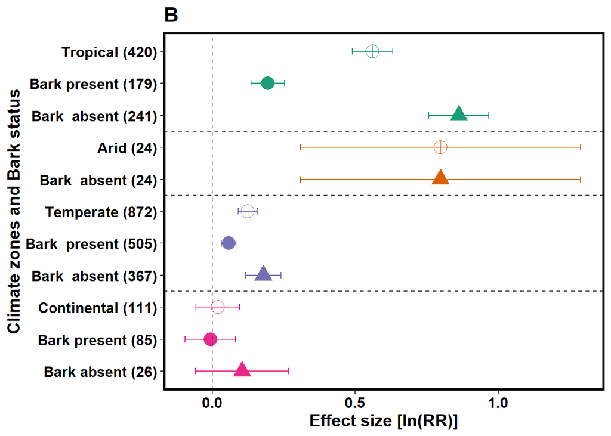

```r
plot9 <- ggplot(dat9, aes(x=point_est, y=label, shape=as.factor(group),color=as.factor(region))) +scale_shape_manual(values = c(10, 16, 17))+
  theme(legend.position="none") +scale_color_brewer(palette="Dark2")+scale_x_continuous(limits = c(-0.1,1.3))+
  geom_point(size=5) + scale_y_discrete(limits = rev(levels(dat9$label))) + geom_vline(xintercept=0, color="black", linetype="dashed", alpha=.5) +
  geom_hline(yintercept = c(3.5,6.5,8.5),color="black", linetype="dashed", alpha=.7)+
  geom_errorbarh(aes(xmin=lb_ci, xmax=ub_ci), height=.2) +
  ggtitle("B")+
  ylab("Climate zones and Bark status") + xlab("Effect size [ln(RR)]") + theme(text = element_text(size = 14,face="bold"), panel.background = element_blank(),
                                                   panel.grid.major = element_blank(),
                                                   panel.grid.minor = element_blank(),
                                                   axis.line = element_line(colour = "black"),
                                                   panel.border = element_rect(colour = "black", fill=NA, size=1.5)) +  theme(axis.text = element_text(family = "palatino", colour = "black", size = (12)))
plot9
```

```r
tr_gymn<-rma(yi, vi, data = tropical, subset = (Clade=="gymnosperm"))
ard_gymn<-rma(yi, vi, data = arid, subset = (Clade=="gymnosperm"))
temp_gymn<-rma(yi, vi, data = temperate, subset = (Clade=="gymnosperm"))
cont_gymn<-rma(yi, vi, data = continental, subset = (Clade=="gymnosperm"))
tr_gymn
```

```
##
## Random-Effects Model (k = 128; tau^2 estimator: REML)
##
## tau^2 (estimated amount of total heterogeneity): 0.5922 (SE = 0.0841)
## tau (square root of estimated tau^2 value):      0.7695
## I^2 (total heterogeneity / total variability):   94.41%
## H^2 (total variability / sampling variability):  17.87
##
## Test for Heterogeneity:
## Q(df = 127) = 2371.1484, p-val < .0001
##
## Model Results:
##
## estimate      se    zval    pval   ci.lb   ci.ub
##   0.5133  0.0726  7.0705  <.0001  0.3710  0.6556  ***
##
## ---
## Signif. codes:  0 '***' 0.001 '**' 0.01 '*' 0.05 '.' 0.1 ' ' 1
```

```r
ard_gymn
```

```
##
## Random-Effects Model (k = 24; tau^2 estimator: REML)
##
## tau^2 (estimated amount of total heterogeneity): 1.3686 (SE = 0.4380)
## tau (square root of estimated tau^2 value):      1.1699
## I^2 (total heterogeneity / total variability):   97.78%
## H^2 (total variability / sampling variability):  45.10
##
## Test for Heterogeneity:
## Q(df = 23) = 737.3757, p-val < .0001
##
## Model Results:
##
## estimate      se    zval    pval   ci.lb   ci.ub
##   0.7977  0.2495  3.1968  0.0014  0.3086  1.2869  **
##
## ---
## Signif. codes:  0 '***' 0.001 '**' 0.01 '*' 0.05 '.' 0.1 ' ' 1
```

```r
temp_gymn
```

```
##
## Random-Effects Model (k = 450; tau^2 estimator: REML)
##
## tau^2 (estimated amount of total heterogeneity): 0.2498 (SE = 0.0213)
## tau (square root of estimated tau^2 value):      0.4998
## I^2 (total heterogeneity / total variability):   99.60%
## H^2 (total variability / sampling variability):  246.97
##
## Test for Heterogeneity:
## Q(df = 449) = 135612.2872, p-val < .0001
##
## Model Results:
##
## estimate      se    zval    pval   ci.lb   ci.ub
##   0.1537  0.0272  5.6424  <.0001  0.1003  0.2071  ***
##
## ---
## Signif. codes:  0 '***' 0.001 '**' 0.01 '*' 0.05 '.' 0.1 ' ' 1
```

```r
cont_gymn
```

```
##
## Random-Effects Model (k = 57; tau^2 estimator: REML)
##
## tau^2 (estimated amount of total heterogeneity): 0.0224 (SE = 0.0109)
## tau (square root of estimated tau^2 value):      0.1496
## I^2 (total heterogeneity / total variability):   53.91%
## H^2 (total variability / sampling variability):  2.17
##
## Test for Heterogeneity:
## Q(df = 56) = 121.8545, p-val < .0001
##
## Model Results:
##
## estimate      se    zval    pval    ci.lb   ci.ub
##   0.0060  0.0361  0.1666  0.8677  -0.0647  0.0768
##
## ---
## Signif. codes:  0 '***' 0.001 '**' 0.01 '*' 0.05 '.' 0.1 ' ' 1
```

```r
tr_angi<-rma(yi, vi, data = tropical, subset = (Clade=="angiosperm"))
#ard_angi<-rma(yi, vi, data = arid, subset = (Clade=="angiosperm"))
temp_angi<-rma(yi, vi, data = temperate, subset = (Clade=="angiosperm"))
cont_angi<-rma(yi, vi, data = continental, subset = (Clade=="angiosperm"))
tr_angi
```

```
##
## Random-Effects Model (k = 292; tau^2 estimator: REML)
##
## tau^2 (estimated amount of total heterogeneity): 0.3909 (SE = 0.0392)
## tau (square root of estimated tau^2 value):      0.6252
## I^2 (total heterogeneity / total variability):   97.02%
## H^2 (total variability / sampling variability):  33.57
##
## Test for Heterogeneity:
## Q(df = 291) = 6198.9408, p-val < .0001
##
## Model Results:
##
## estimate      se     zval    pval   ci.lb   ci.ub
##   0.5791  0.0408  14.1919  <.0001  0.4991  0.6590  ***
##
## ---
## Signif. codes:  0 '***' 0.001 '**' 0.01 '*' 0.05 '.' 0.1 ' ' 1
```

```r
#ard_angi
temp_angi
```

```
##
## Random-Effects Model (k = 422; tau^2 estimator: REML)
##
## tau^2 (estimated amount of total heterogeneity): 0.0602 (SE = 0.0072)
## tau (square root of estimated tau^2 value):      0.2454
## I^2 (total heterogeneity / total variability):   99.37%
## H^2 (total variability / sampling variability):  157.57
##
## Test for Heterogeneity:
## Q(df = 421) = 225938.1768, p-val < .0001
##
## Model Results:
##
## estimate      se    zval    pval   ci.lb   ci.ub
##   0.0840  0.0169  4.9717  <.0001  0.0509  0.1171  ***
##
## ---
## Signif. codes:  0 '***' 0.001 '**' 0.01 '*' 0.05 '.' 0.1 ' ' 1
```

```r
cont_angi
```

```
##
## Random-Effects Model (k = 54; tau^2 estimator: REML)
##
## tau^2 (estimated amount of total heterogeneity): 0.1986 (SE = 0.0751)
## tau (square root of estimated tau^2 value):      0.4456
## I^2 (total heterogeneity / total variability):   62.99%
## H^2 (total variability / sampling variability):  2.70
##
## Test for Heterogeneity:
## Q(df = 53) = 113.7440, p-val < .0001
##
## Model Results:
##
## estimate      se    zval    pval    ci.lb   ci.ub
##   0.0382  0.0924  0.4138  0.6790  -0.1429  0.2194
##
## ---
## Signif. codes:  0 '***' 0.001 '**' 0.01 '*' 0.05 '.' 0.1 ' ' 1
```

```r
dat10 <- data.frame(
  label = c("Tropical (420)","Gymnosperm (128)", "Angiosperm (292)","Arid (24)","Gymnosperm (24)",
             "Temperate (872)","Gymnosperm (450)","Angiosperm (422)","Continental (111)", "Gymnosperm (57)", "Angiosperm (54)"),
  point_est = c(0.5602,0.5133,0.5791,0.7977,0.7977,  0.1242, 0.1537,0.0840,0.0199,0.0060,0.0382 ),
  lb_ci = c(0.4894,0.3710,0.4991, 0.3086,0.3086,0.0911,0.1003,0.0509,-0.0560, -0.0647,-0.1429 ),
  ub_ci = c(0.6309,0.6556,0.6590,1.2869,1.2869,0.1573,0.2071,0.1171,0.0959,0.0768,0.2194 ),
  group = c(1,2,3,1,2,1,2,3,1,2,3),
  region= c(1,1,1,2,2,3,3,3,4,4,4)
)
dat10$label <- factor(dat10$label, levels = dat10$label)
as.factor(dat10$group)
```

```
##  [1] 1 2 3 1 2 1 2 3 1 2 3
## Levels: 1 2 3
```

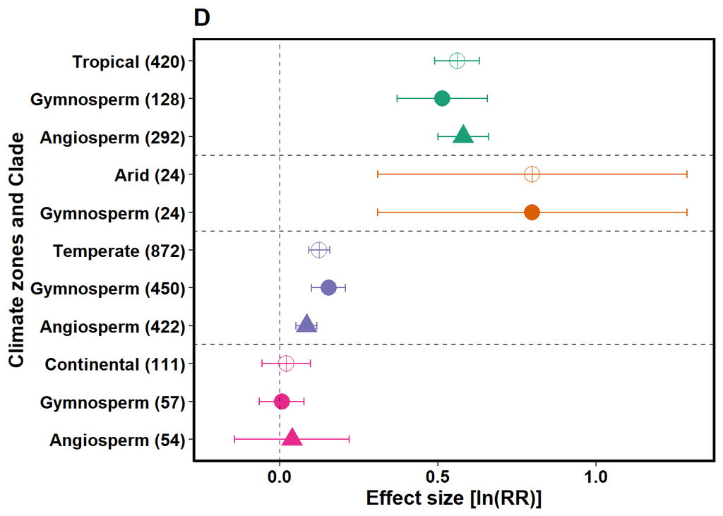

```r
plot10 <- ggplot(dat10, aes(x=point_est, y=label, shape=as.factor(group),color=as.factor(region))) +scale_shape_manual(values = c(10, 16, 17))+
  theme(legend.position="none") +scale_color_brewer(palette="Dark2")+scale_x_continuous(limits = c(-0.2,1.3))+
  geom_point(size=5) + scale_y_discrete(limits = rev(levels(dat10$label))) + geom_vline(xintercept=0, color="black", linetype="dashed", alpha=.5) +
  geom_hline(yintercept = c(3.5,6.5,8.5),color="black", linetype="dashed", alpha=.7)+
  geom_errorbarh(aes(xmin=lb_ci, xmax=ub_ci), height=.2) +
  ggtitle("D")+
  ylab("Climate zones and Clade") + xlab("Effect size [ln(RR)]") + theme(text = element_text(size = 14,face="bold"), panel.background = element_blank(),
                                                   panel.grid.major = element_blank(),
                                                   panel.grid.minor = element_blank(),
                                                   axis.line = element_line(colour = "black"),
                                                   panel.border = element_rect(colour = "black", fill=NA, size=1.5)) +  theme(axis.text = element_text(family = "palatino", colour = "black", size = (12)))
plot10
```

```r
tr_natural<-rma(yi, vi, data = tropical, subset = (natural_wood_or_block=="natural"))
#ard_natural<-rma(yi, vi, data = arid, subset = (natural_wood_or_block=="natural"))
temp_natural<-rma(yi, vi, data = temperate, subset = (natural_wood_or_block=="natural"))
cont_natural<-rma(yi, vi, data = continental, subset = (natural_wood_or_block=="natural"))
tr_natural
```

```
##
## Random-Effects Model (k = 299; tau^2 estimator: REML)
##
## tau^2 (estimated amount of total heterogeneity): 0.4198 (SE = 0.0416)
## tau (square root of estimated tau^2 value):      0.6479
## I^2 (total heterogeneity / total variability):   97.12%
## H^2 (total variability / sampling variability):  34.70
##
## Test for Heterogeneity:
## Q(df = 298) = 6334.5617, p-val < .0001
##
## Model Results:
##
## estimate      se     zval    pval   ci.lb   ci.ub
##   0.6397  0.0418  15.3164  <.0001  0.5579  0.7216  ***
##
## ---
## Signif. codes:  0 '***' 0.001 '**' 0.01 '*' 0.05 '.' 0.1 ' ' 1
```

```r
#ard_natural
temp_natural
```

```
##
## Random-Effects Model (k = 516; tau^2 estimator: REML)
##
## tau^2 (estimated amount of total heterogeneity): 0.0318 (SE = 0.0044)
## tau (square root of estimated tau^2 value):      0.1783
## I^2 (total heterogeneity / total variability):   57.69%
## H^2 (total variability / sampling variability):  2.36
##
## Test for Heterogeneity:
## Q(df = 515) = 1085.3929, p-val < .0001
##
## Model Results:
##
## estimate      se    zval    pval   ci.lb   ci.ub
##   0.0514  0.0130  3.9717  <.0001  0.0261  0.0768  ***
##
## ---
## Signif. codes:  0 '***' 0.001 '**' 0.01 '*' 0.05 '.' 0.1 ' ' 1
```

```r
cont_natural
```

```
##
## Random-Effects Model (k = 85; tau^2 estimator: REML)
##
## tau^2 (estimated amount of total heterogeneity): 0.0615 (SE = 0.0215)
## tau (square root of estimated tau^2 value):      0.2479
## I^2 (total heterogeneity / total variability):   65.98%
## H^2 (total variability / sampling variability):  2.94
##
## Test for Heterogeneity:
## Q(df = 84) = 183.2620, p-val < .0001
##
## Model Results:
##
## estimate      se     zval    pval    ci.lb   ci.ub
##  -0.0060  0.0450  -0.1339  0.8935  -0.0941  0.0821
##
## ---
## Signif. codes:  0 '***' 0.001 '**' 0.01 '*' 0.05 '.' 0.1 ' ' 1
```

```r
tr_blocks<-rma(yi, vi, data = tropical, subset = (natural_wood_or_block=="block"))
ard_blocks<-rma(yi, vi, data = arid, subset = (natural_wood_or_block=="block"))
temp_blocks<-rma(yi, vi, data = temperate, subset = (natural_wood_or_block=="block"))
cont_blocks<-rma(yi, vi, data = continental, subset = (natural_wood_or_block=="block"))
tr_blocks
```

```
##
## Random-Effects Model (k = 121; tau^2 estimator: REML)
##
## tau^2 (estimated amount of total heterogeneity): 0.4951 (SE = 0.0722)
## tau (square root of estimated tau^2 value):      0.7036
## I^2 (total heterogeneity / total variability):   94.18%
## H^2 (total variability / sampling variability):  17.19
##
## Test for Heterogeneity:
## Q(df = 120) = 2206.5131, p-val < .0001
##
## Model Results:
##
## estimate      se    zval    pval   ci.lb   ci.ub
##   0.3690  0.0682  5.4079  <.0001  0.2353  0.5028  ***
##
## ---
## Signif. codes:  0 '***' 0.001 '**' 0.01 '*' 0.05 '.' 0.1 ' ' 1
```

```r
ard_blocks
```

```
##
## Random-Effects Model (k = 24; tau^2 estimator: REML)
##
## tau^2 (estimated amount of total heterogeneity): 1.3686 (SE = 0.4380)
## tau (square root of estimated tau^2 value):      1.1699
## I^2 (total heterogeneity / total variability):   97.78%
## H^2 (total variability / sampling variability):  45.10
##
## Test for Heterogeneity:
## Q(df = 23) = 737.3757, p-val < .0001
##
## Model Results:
##
## estimate      se    zval    pval   ci.lb   ci.ub
##   0.7977  0.2495  3.1968  0.0014  0.3086  1.2869  **
##
## ---
## Signif. codes:  0 '***' 0.001 '**' 0.01 '*' 0.05 '.' 0.1 ' ' 1
```

```r
temp_blocks
```

```
##
## Random-Effects Model (k = 356; tau^2 estimator: REML)
##
## tau^2 (estimated amount of total heterogeneity): 0.2996 (SE = 0.0271)
## tau (square root of estimated tau^2 value):      0.5474
## I^2 (total heterogeneity / total variability):   99.93%
## H^2 (total variability / sampling variability):  1393.83
##
## Test for Heterogeneity:
## Q(df = 355) = 564315.1265, p-val < .0001
##
## Model Results:
##
## estimate      se    zval    pval   ci.lb   ci.ub
##   0.1879  0.0322  5.8374  <.0001  0.1248  0.2510  ***
##
## ---
## Signif. codes:  0 '***' 0.001 '**' 0.01 '*' 0.05 '.' 0.1 ' ' 1
```

```r
cont_blocks
```

```
##
## Random-Effects Model (k = 26; tau^2 estimator: REML)
##
## tau^2 (estimated amount of total heterogeneity): 0.0699 (SE = 0.0413)
## tau (square root of estimated tau^2 value):      0.2644
## I^2 (total heterogeneity / total variability):   62.87%
## H^2 (total variability / sampling variability):  2.69
##
## Test for Heterogeneity:
## Q(df = 25) = 49.9629, p-val = 0.0022
##
## Model Results:
##
## estimate      se    zval    pval    ci.lb   ci.ub
##   0.1045  0.0830  1.2598  0.2077  -0.0581  0.2671
##
## ---
## Signif. codes:  0 '***' 0.001 '**' 0.01 '*' 0.05 '.' 0.1 ' ' 1
```

```r
dat11 <- data.frame(
  label = c("Tropics (420)","Natural WD (299)", "Processed WD (121)","Arid (24)",
            "Processed WD (24)", "Temperate (872)","Natural WD (516)","Processed WD (356)","Continental (111)", "Natural WD (85)", "Processed WD (26)"),
  point_est = c(0.5602,0.6397,0.3690, 0.7977,0.7977, 0.1242,0.0514, 0.1879,  0.0199,-0.0060, 0.1045),
  lb_ci = c(0.4894,0.5579,0.2353,0.3086,0.3086,0.0911,0.0261,0.1248,-0.0560,-0.0941,-0.0581),
  ub_ci = c(0.6309,0.7216,0.5028,1.2869,1.2869,0.1573,0.0768,0.2510,0.0959,0.0821,0.2671 ),
  group = c(1,2,3,1,3,1,2,3,1,2,3),
  region= c(1,1,1,2,2,3,3,3,4,4,4)
)
dat11$label <- factor(dat11$label, levels = dat11$label)
as.factor(dat11$group)
```

```
##  [1] 1 2 3 1 3 1 2 3 1 2 3
## Levels: 1 2 3
```

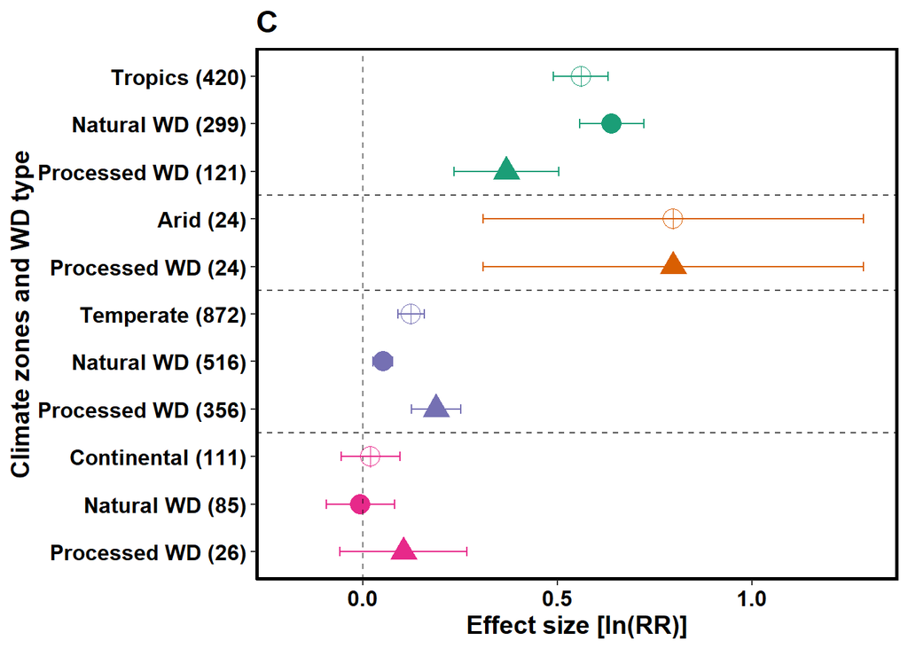

```r
plot11 <- ggplot(dat11, aes(x=point_est, y=label, shape=as.factor(group),color=as.factor(region))) +scale_shape_manual(values = c(10, 16, 17))+
  theme(legend.position="none") +scale_color_brewer(palette="Dark2")+scale_x_continuous(limits = c(-0.2,1.3))+
  geom_point(size=5) + scale_y_discrete(limits = rev(levels(dat11$label))) + geom_vline(xintercept=0, color="black", linetype="dashed", alpha=.5) +
  geom_hline(yintercept = c(3.5,6.5,8.5),color="black", linetype="dashed", alpha=.7)+
  geom_errorbarh(aes(xmin=lb_ci, xmax=ub_ci), height=.2) +
  ggtitle("C")+
  ylab("Climate zones and WD type") + xlab("Effect size [ln(RR)]") + theme(text = element_text(size = 14,face="bold"), panel.background = element_blank(),
                                                   panel.grid.major = element_blank(),
                                                   panel.grid.minor = element_blank(),
                                                   axis.line = element_line(colour = "black"),
                                                   panel.border = element_rect(colour = "black", fill=NA, size=1.5)) +  theme(axis.text = element_text(family = "palatino", colour = "black", size = (12)))
plot11
```

```r
tr_sm<-rma(yi, vi, data = tropical, subset = (diameter_class=="small"))
#ard_sm<-rma(yi, vi, data = arid, subset = (diameter_class=="small"))
temp_sm<-rma(yi, vi, data = temperate, subset = (diameter_class=="small"))
cont_sm<-rma(yi, vi, data = continental, subset = (diameter_class=="small"))
tr_sm
```

```
##
## Random-Effects Model (k = 175; tau^2 estimator: REML)
##
## tau^2 (estimated amount of total heterogeneity): 0.0960 (SE = 0.0142)
## tau (square root of estimated tau^2 value):      0.3099
## I^2 (total heterogeneity / total variability):   90.36%
## H^2 (total variability / sampling variability):  10.38
##
## Test for Heterogeneity:
## Q(df = 174) = 1430.0806, p-val < .0001
##
## Model Results:
##
## estimate      se    zval    pval   ci.lb   ci.ub
##   0.1732  0.0285  6.0764  <.0001  0.1173  0.2290  ***
##
## ---
## Signif. codes:  0 '***' 0.001 '**' 0.01 '*' 0.05 '.' 0.1 ' ' 1
```

```r
#ard_sm
temp_sm
```

```
##
## Random-Effects Model (k = 459; tau^2 estimator: REML)
##
## tau^2 (estimated amount of total heterogeneity): 0.2414 (SE = 0.0209)
## tau (square root of estimated tau^2 value):      0.4913
## I^2 (total heterogeneity / total variability):   99.89%
## H^2 (total variability / sampling variability):  870.85
##
## Test for Heterogeneity:
## Q(df = 458) = 563711.7319, p-val < .0001
##
## Model Results:
##
## estimate      se    zval    pval   ci.lb   ci.ub
##   0.1638  0.0271  6.0379  <.0001  0.1107  0.2170  ***
##
## ---
## Signif. codes:  0 '***' 0.001 '**' 0.01 '*' 0.05 '.' 0.1 ' ' 1
```

```r
cont_sm
```

```
##
## Random-Effects Model (k = 98; tau^2 estimator: REML)
##
## tau^2 (estimated amount of total heterogeneity): 0.0908 (SE = 0.0272)
## tau (square root of estimated tau^2 value):      0.3013
## I^2 (total heterogeneity / total variability):   71.71%
## H^2 (total variability / sampling variability):  3.53
##
## Test for Heterogeneity:
## Q(df = 97) = 220.0614, p-val < .0001
##
## Model Results:
##
## estimate      se    zval    pval    ci.lb   ci.ub
##   0.0287  0.0487  0.5892  0.5558  -0.0667  0.1241
##
## ---
## Signif. codes:  0 '***' 0.001 '**' 0.01 '*' 0.05 '.' 0.1 ' ' 1
```

```r
tr_lar<-rma(yi, vi, data = tropical, subset = (diameter_class=="large"))
ard_lar<-rma(yi, vi, data = arid, subset = (diameter_class=="large"))
temp_lar<-rma(yi, vi, data = temperate, subset = (diameter_class=="large"))
cont_lar<-rma(yi, vi, data = continental, subset = (diameter_class=="large"))
tr_lar
```

```
##
## Random-Effects Model (k = 245; tau^2 estimator: REML)
##
## tau^2 (estimated amount of total heterogeneity): 0.5623 (SE = 0.0601)
## tau (square root of estimated tau^2 value):      0.7498
## I^2 (total heterogeneity / total variability):   96.00%
## H^2 (total variability / sampling variability):  24.98
##
## Test for Heterogeneity:
## Q(df = 244) = 6011.0523, p-val < .0001
##
## Model Results:
##
## estimate      se     zval    pval   ci.lb   ci.ub
##   0.8559  0.0524  16.3425  <.0001  0.7532  0.9585  ***
##
## ---
## Signif. codes:  0 '***' 0.001 '**' 0.01 '*' 0.05 '.' 0.1 ' ' 1
```

```r
ard_lar
```

```
##
## Random-Effects Model (k = 24; tau^2 estimator: REML)
##
## tau^2 (estimated amount of total heterogeneity): 1.3686 (SE = 0.4380)
## tau (square root of estimated tau^2 value):      1.1699
## I^2 (total heterogeneity / total variability):   97.78%
## H^2 (total variability / sampling variability):  45.10
##
## Test for Heterogeneity:
## Q(df = 23) = 737.3757, p-val < .0001
##
## Model Results:
##
## estimate      se    zval    pval   ci.lb   ci.ub
##   0.7977  0.2495  3.1968  0.0014  0.3086  1.2869  **
##
## ---
## Signif. codes:  0 '***' 0.001 '**' 0.01 '*' 0.05 '.' 0.1 ' ' 1
```

```r
temp_lar
```

```
##
## Random-Effects Model (k = 413; tau^2 estimator: REML)
##
## tau^2 (estimated amount of total heterogeneity): 0.0718 (SE = 0.0083)
## tau (square root of estimated tau^2 value):      0.2680
## I^2 (total heterogeneity / total variability):   78.59%
## H^2 (total variability / sampling variability):  4.67
##
## Test for Heterogeneity:
## Q(df = 412) = 1365.7953, p-val < .0001
##
## Model Results:
##
## estimate      se    zval    pval   ci.lb   ci.ub
##   0.0739  0.0178  4.1424  <.0001  0.0389  0.1089  ***
##
## ---
## Signif. codes:  0 '***' 0.001 '**' 0.01 '*' 0.05 '.' 0.1 ' ' 1
```

```r
cont_lar
```

```
##
## Random-Effects Model (k = 13; tau^2 estimator: REML)
##
## tau^2 (estimated amount of total heterogeneity): 0 (SE = 0.0052)
## tau (square root of estimated tau^2 value):      0
## I^2 (total heterogeneity / total variability):   0.00%
## H^2 (total variability / sampling variability):  1.00
##
## Test for Heterogeneity:
## Q(df = 12) = 6.6408, p-val = 0.8804
##
## Model Results:
##
## estimate      se     zval    pval    ci.lb   ci.ub
##  -0.0628  0.0374  -1.6800  0.0930  -0.1362  0.0105  .
##
## ---
## Signif. codes:  0 '***' 0.001 '**' 0.01 '*' 0.05 '.' 0.1 ' ' 1
```

```r
dat13 <- data.frame(
  label = c("Tropical (420)","Smaller (≤ 3 cm) diameter WD (175)", "Larger (> 3 cm) diameter WD (245)","Arid (24)",
            "Larger (> 3 cm) diameter WD (24)", "Temperate (872)","Smaller (≤ 3 cm) diameter WD (459)","Larger (> 3 cm) diameter WD (413)","Continental (111)", "Smaller (≤ 3 cm) diameter WD (98)", "Larger (> 3 cm) diameter WD (13)"),
  point_est = c(0.5602, 0.1732,0.8559,0.7977,  0.7977, 0.1242,  0.1638,0.0739,0.0199,0.0287,-0.0628),
  lb_ci = c( 0.4894,0.1173 ,0.7532,0.3086, 0.3086,0.0911,0.1107,0.0389,-0.0560,-0.0667,-0.1362   ),
  ub_ci = c(0.6309,0.2290,0.9585,1.2869, 1.2869,0.1573,0.2170, 0.1089, 0.0959,0.1241,0.0105 ),
  group = c(1,2,3,1,3,1,2,3,1,2,3),
  region= c(1,1,1,2,2,3,3,3,4,4,4)
)
dat13$label <- factor(dat13$label, levels = dat13$label)
as.factor(dat13$group)
```

```
##  [1] 1 2 3 1 3 1 2 3 1 2 3
## Levels: 1 2 3
```

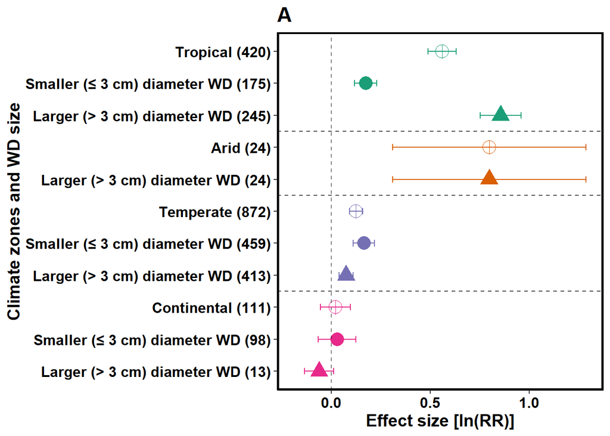

```r
plot13 <- ggplot(dat13, aes(x=point_est, y=label, shape=as.factor(group),color=as.factor(region))) +scale_shape_manual(values = c(10, 16, 17))+
  theme(legend.position="none") +scale_color_brewer(palette="Dark2")+scale_x_continuous(limits = c(-0.2,1.3))+
  geom_point(size=5) + scale_y_discrete(limits = rev(levels(dat13$label))) + geom_vline(xintercept=0, color="black", linetype="dashed", alpha=.5) +
  geom_hline(yintercept = c(3.5,6.5,8.5),color="black", linetype="dashed", alpha=.7)+
  geom_errorbarh(aes(xmin=lb_ci, xmax=ub_ci), height=.2) +
  ggtitle("A")+
  ylab("Climate zones and WD size") + xlab("Effect size [ln(RR)]") + theme(text = element_text(size = 14,face="bold"), panel.background = element_blank(),
                                                   panel.grid.major = element_blank(),
                                                   panel.grid.minor = element_blank(),
                                                   axis.line = element_line(colour = "black"),
                                                   panel.border = element_rect(colour = "black", fill=NA, size=1.5)) +  theme(axis.text = element_text(family = "palatino", colour = "black", size = (12)))
plot13
```

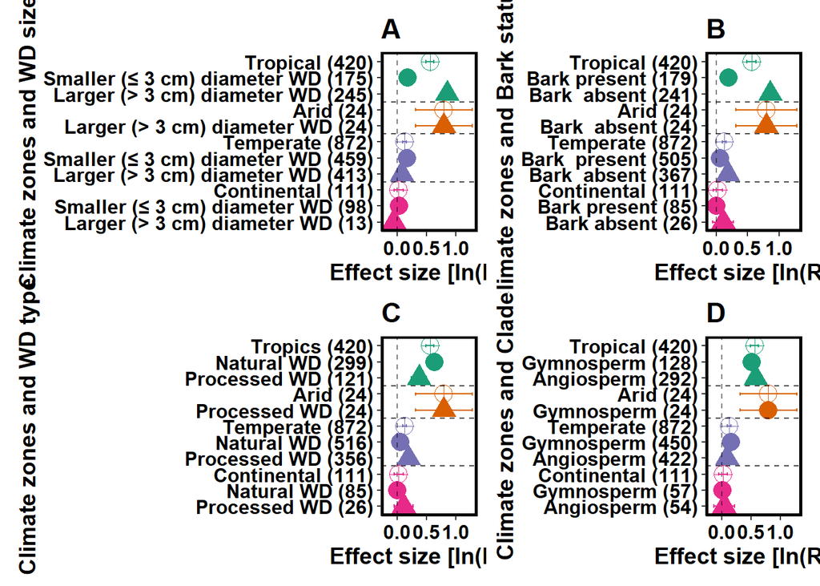

```r
library(patchwork)
figx<- plot13+ plot9 + plot11 +plot10
figx
```

```r
ggsave(filename="Figure 4 Effect of woody debris diameterBark_across_climates.png", plot=figx, device="png",
       path=path, height=8, width=12, units="in", dpi=500)
```

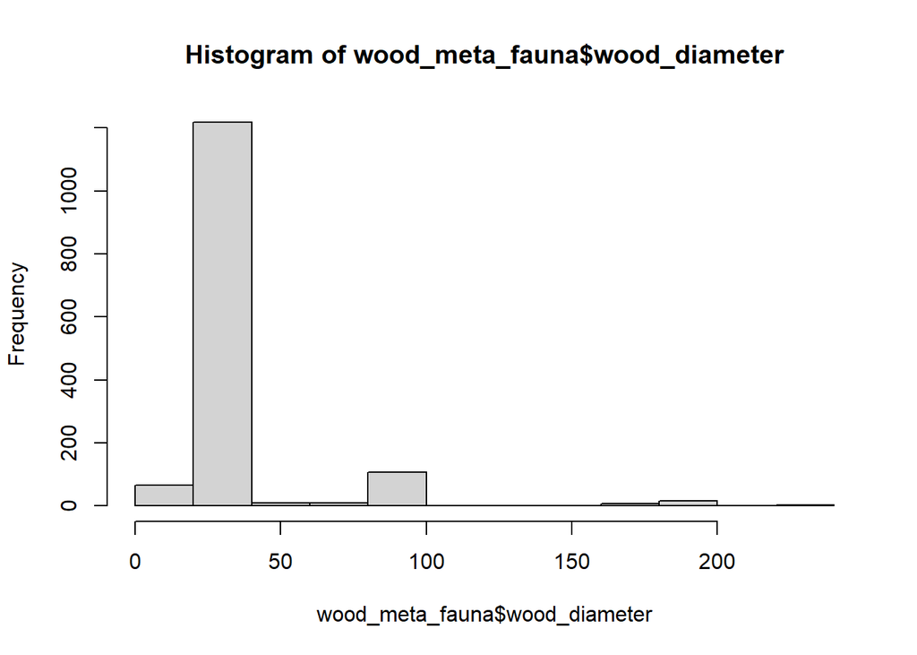

```r
hist(wood_meta_fauna$wood_diameter)
```

```r
summary(wood_meta_fauna$wood_diameter)
```

```
##    Min. 1st Qu.  Median    Mean 3rd Qu.    Max.
##    3.50   30.00   30.00   40.46   40.00  231.00
```

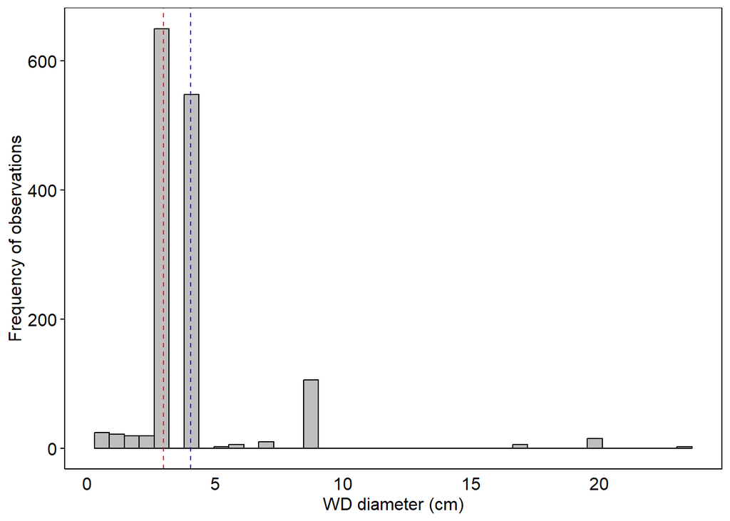

```r
p_his<-ggplot(wood_meta_fauna, aes(x=wood_diameter/10)) +
  geom_histogram(color="black", fill="grey",bins=40)+ geom_vline(aes(xintercept=mean(wood_diameter/10)),
            color="blue", linetype="dashed", size=0.5)+geom_vline(aes(xintercept=median(wood_diameter/10)),
            color="red", linetype="dashed", size=0.5)+labs(x="WD diameter (cm)", y = "Frequency of observations")+

  theme(axis.line = element_line(colour = "black", size = 0.5),
        axis.ticks.x=element_blank(),
        axis.ticks.y=element_line(colour = "black"),
        axis.text = element_text(colour = "black", size = 15),
        axis.title = element_text(colour = "black", size = 15),
        panel.grid.major = element_blank(),
        panel.grid.minor = element_blank(),
        panel.border = element_rect(fill=NA,color="black", size=0.5, linetype="solid"),
        panel.background = element_blank(),
        strip.text = element_text(colour = "black", size = 15),
        #legend.position = c("bottom"),
        legend.position = "none",
        legend.text=element_text(size=12,face="italic"),
        legend.background = element_blank(),
        legend.key.width=unit(0.2,"cm"),
        legend.key.height=unit(0.2,"cm"))+
  theme(text=element_text(size=12,  family="serif"))+ theme(axis.title = element_text(family = "palatino", size = (12), colour = "black"))+
  theme(axis.text = element_text(family = "palatino", colour = "black", size = (12)))
p_his
```

```r
ggsave(filename="Figure S3 Diameter hist.png", plot=p_his, device="png",
       path=path, height=4, width=5, units="in", dpi=500)
```

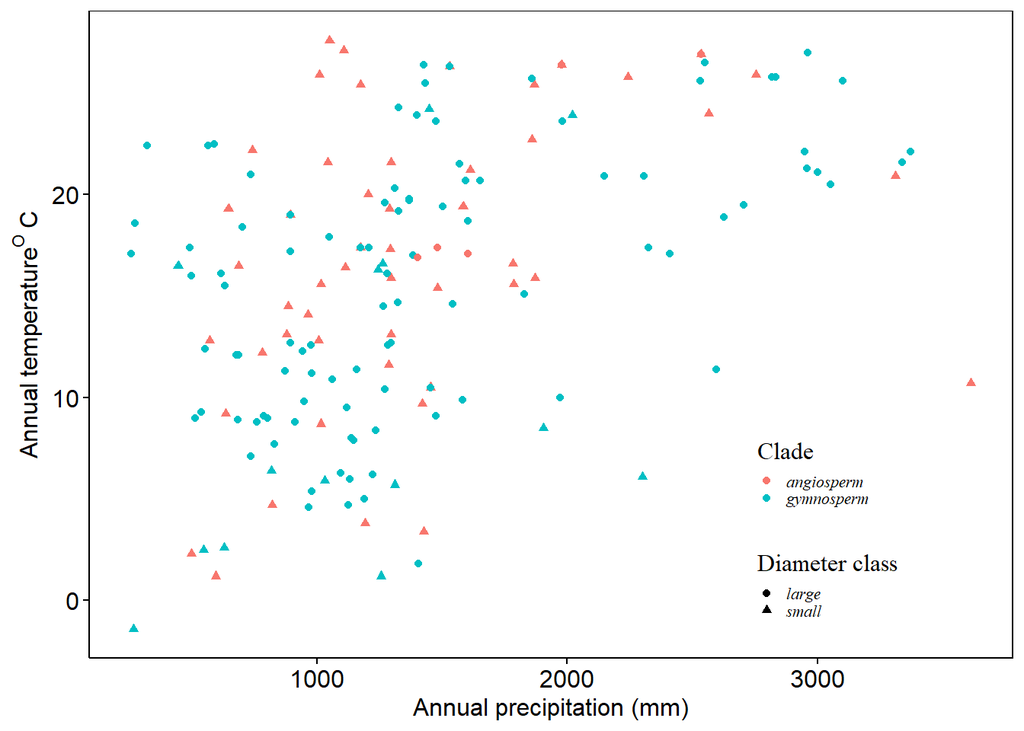

```r
prep_temp<-ggplot(wood_meta_fauna, aes(x= Precip, y= temperature, color=Clade , shape=diameter_class)) +
geom_point()+xlab("Annual precipitation (mm)") + ylab(bquote(Annual~temperature   ^O~C))+
  theme(axis.line = element_line(colour = "black", size = 0.5),
        axis.ticks.x=element_line(colour = "black"),
        axis.ticks.y=element_line(colour = "black"),
        axis.text = element_text(colour = "black", size = 12),
        axis.title = element_text(colour = "black", size = 12),
        panel.grid.major = element_blank(),
        panel.grid.minor = element_blank(),
        panel.border = element_rect(fill=NA,color="black", size=0.5, linetype="solid"),
        panel.background = element_blank(),
        strip.text = element_text(colour = "black", size = 12),
       #legend.position = c("bottom"),
        legend.position = c(0.8, 0.2),
        legend.text=element_text(size=8,face="italic"),
        legend.background = element_blank(),
        legend.key.width=unit(0.3,"cm"),
        legend.key.height=unit(0.3,"cm"))+
    labs(color="Clade",shape="Diameter class")+
  theme(text=element_text(size=12,  family="serif"))+ theme(axis.title = element_text(family = "palatino", size = (12), colour = "black"))+
  theme(axis.text = element_text(family = "palatino", colour = "black", size = (12)))
prep_temp
```

```r
ggsave(filename="gymn_ang_temp.png", plot=prep_temp, device="png",
       path=path, height=4, width=5, units="in", dpi=500)
```

# 8 Metaregression

From a broader perspective, meta-analysis and meta-regression are part of a systematic, integrative process to make sense of publicly available yet disperse, imprecise, and heterogeneous information

Meta-regression is regarded as an extension of meta-analysis. Because there is substantial unaccounted heterogeneity in the outcome of interest across studies, we continue investigating whether such heterogeneity may be further explained by differences in characteristics of the studies (methodological diversity) or study populations. This step helps to better understand whether and which study-level factors drive the measures of effect.

## 8.1 metaregression interpretation

Typical meta-regression analysis will produce a number of parameters describing the model heterogeneity:

**τ2**: Is an estimate of the residual between variance (between variance not captured by the fixed part of the model) expressed in squared units of the effect estimate. **τ**: A measure of residual between dispersion expressed in the same units as the effect estimate. **I2**: Estimates how much of the unaccounted variability (residual heterogeneity + sampling error) is attributable to residual heterogeneity expressed as a percentage. **H2**: It estimates the ratio of the unaccounted variability relative to the sampling variability. In other words, it provides an estimate of how much our uncertainty about the parameter of interest is inflated due to consideration of all sources of variance, as opposed to a model where only within variance contributes to the width of the confidence intervals. **R2adj**: It is the estimated % of heterogeneity accounted for by the addition of predictors into the model as compared to an “empty” model. In other words, it is the percentage of the heterogeneity explained by the group-level variables in the model. **Q**: It is a χ2-based test statistic contrasting observed differences between studies vs. the differences expected by chance. Q is typically an under-powered statistic, and that the typical analytical scenario for meta-regression, where only a small number of observations is available may lead to both high rates of false discovery and failure to detect an existing association.

## 8.2 Test how single moderators influence the effect size

### 8.2.1 Climate zone

```r
m_reg <- rma(yi = yi, vi = vi, mods = ~climate_zone, data = wood_meta_fauna)
m_reg
```

```
##
## Mixed-Effects Model (k = 1427; tau^2 estimator: REML)
##
## tau^2 (estimated amount of residual heterogeneity):     0.2584 (SE = 0.0126)
## tau (square root of estimated tau^2 value):             0.5083
## I^2 (residual heterogeneity / unaccounted variability): 99.68%
## H^2 (unaccounted variability / sampling variability):   311.01
## R^2 (amount of heterogeneity accounted for):            11.67%
##
## Test for Residual Heterogeneity:
## QE(df = 1423) = 581454.0558, p-val < .0001
##
## Test of Moderators (coefficients 2:4):
## QM(df = 3) = 174.2892, p-val < .0001
##
## Model Results:
##
##                          estimate      se      zval    pval    ci.lb    ci.ub
## intrcpt                    0.5371  0.0285   18.8546  <.0001   0.4813   0.5930
## climate_zoneArid           0.2455  0.1239    1.9809  0.0476   0.0026   0.4885
## climate_zoneTemperate     -0.4113  0.0348  -11.8073  <.0001  -0.4795  -0.3430
## climate_zoneContinental   -0.5297  0.0689   -7.6854  <.0001  -0.6648  -0.3946
##
## intrcpt                  ***
## climate_zoneArid           *
## climate_zoneTemperate    ***
## climate_zoneContinental  ***
##
## ---
## Signif. codes:  0 '***' 0.001 '**' 0.01 '*' 0.05 '.' 0.1 ' ' 1
```

climate zones is significant and alone explains 11.67 % of the variability in the effect size

### 8.2.2 Bark status

```r
bark_metareg <- rma(yi = yi, vi = vi, mods = ~Bark_status_presence_or_absent, data = wood_meta_fauna)
bark_metareg
```

```
##
## Mixed-Effects Model (k = 1427; tau^2 estimator: REML)
##
## tau^2 (estimated amount of residual heterogeneity):     0.2702 (SE = 0.0130)
## tau (square root of estimated tau^2 value):             0.5198
## I^2 (residual heterogeneity / unaccounted variability): 99.69%
## H^2 (unaccounted variability / sampling variability):   324.55
## R^2 (amount of heterogeneity accounted for):            7.63%
##
## Test for Residual Heterogeneity:
## QE(df = 1425) = 575823.3368, p-val < .0001
##
## Test of Moderators (coefficient 2):
## QM(df = 1) = 101.9790, p-val < .0001
##
## Model Results:
##
##                                        estimate      se      zval    pval
## intrcpt                                  0.4253  0.0232   18.3228  <.0001
## Bark_status_presence_or_absentpresent   -0.3238  0.0321  -10.0985  <.0001
##                                          ci.lb    ci.ub
## intrcpt                                 0.3798   0.4708  ***
## Bark_status_presence_or_absentpresent  -0.3866  -0.2609  ***
##
## ---
## Signif. codes:  0 '***' 0.001 '**' 0.01 '*' 0.05 '.' 0.1 ' ' 1
```

Bark status is significant and alone explains 7.63 % of the variability in the effect size. invertebrates on WD with bark present is lower compared to that of WD without bark

### 8.2.3 WD diameter

```r
diameter_metareg <- rma(yi = yi, vi = vi, mods = ~wood_diameter , data = wood_meta_fauna)
diameter_metareg
```

```
##
## Mixed-Effects Model (k = 1427; tau^2 estimator: REML)
##
## tau^2 (estimated amount of residual heterogeneity):     0.2926 (SE = 0.0140)
## tau (square root of estimated tau^2 value):             0.5409
## I^2 (residual heterogeneity / unaccounted variability): 99.72%
## H^2 (unaccounted variability / sampling variability):   352.01
## R^2 (amount of heterogeneity accounted for):            0.00%
##
## Test for Residual Heterogeneity:
## QE(df = 1425) = 583180.4481, p-val < .0001
##
## Test of Moderators (coefficient 2):
## QM(df = 1) = 0.7084, p-val = 0.4000
##
## Model Results:
##
##                estimate      se     zval    pval    ci.lb   ci.ub
## intrcpt          0.2789  0.0310   9.0025  <.0001   0.2182  0.3396  ***
## wood_diameter   -0.0005  0.0007  -0.8416  0.4000  -0.0018  0.0007
##
## ---
## Signif. codes:  0 '***' 0.001 '**' 0.01 '*' 0.05 '.' 0.1 ' ' 1
```

Wood diameter is not significant.

### 8.2.4 WD type (natural / block)

```r
WD_type_metareg <- rma(yi = yi, vi = vi, mods = ~natural_wood_or_block , data = wood_meta_fauna)
WD_type_metareg
```

```
##
## Mixed-Effects Model (k = 1427; tau^2 estimator: REML)
##
## tau^2 (estimated amount of residual heterogeneity):     0.2929 (SE = 0.0140)
## tau (square root of estimated tau^2 value):             0.5412
## I^2 (residual heterogeneity / unaccounted variability): 99.72%
## H^2 (unaccounted variability / sampling variability):   351.65
## R^2 (amount of heterogeneity accounted for):            0.00%
##
## Test for Residual Heterogeneity:
## QE(df = 1425) = 576497.1270, p-val < .0001
##
## Test of Moderators (coefficient 2):
## QM(df = 1) = 0.0285, p-val = 0.8660
##
## Model Results:
##
##                               estimate      se    zval    pval    ci.lb   ci.ub
## intrcpt                         0.2534  0.0264  9.6071  <.0001   0.2017  0.3051
## natural_wood_or_blocknatural    0.0057  0.0339  0.1687  0.8660  -0.0607  0.0721
##
## intrcpt                       ***
## natural_wood_or_blocknatural
##
## ---
## Signif. codes:  0 '***' 0.001 '**' 0.01 '*' 0.05 '.' 0.1 ' ' 1
```

The type of WD used in the experiment (block vs natural) does not influence invertebrates effect on WD.

### 8.2.5 Study incubation duration

```r
duration_metareg <- rma(yi = yi, vi = vi, mods = ~Study_duration_months , data = wood_meta_fauna)
duration_metareg
```

```
##
## Mixed-Effects Model (k = 1427; tau^2 estimator: REML)
##
## tau^2 (estimated amount of residual heterogeneity):     0.2757 (SE = 0.0133)
## tau (square root of estimated tau^2 value):             0.5251
## I^2 (residual heterogeneity / unaccounted variability): 99.67%
## H^2 (unaccounted variability / sampling variability):   307.63
## R^2 (amount of heterogeneity accounted for):            5.75%
##
## Test for Residual Heterogeneity:
## QE(df = 1425) = 537311.1968, p-val < .0001
##
## Test of Moderators (coefficient 2):
## QM(df = 1) = 101.7455, p-val < .0001
##
## Model Results:
##
##                        estimate      se      zval    pval    ci.lb    ci.ub
## intrcpt                  0.5645  0.0346   16.3196  <.0001   0.4967   0.6323
## Study_duration_months   -0.0156  0.0015  -10.0869  <.0001  -0.0186  -0.0125
##
## intrcpt                ***
## Study_duration_months  ***
##
## ---
## Signif. codes:  0 '***' 0.001 '**' 0.01 '*' 0.05 '.' 0.1 ' ' 1
```

The incubation duration also has a significant effect on the overall invertebrates effect on WD decomposition. It explains 5.75 % of the variability in the effect size. Invertebrates effect on WD debris decreases with time.

### 8.2.6 Clade (gymnosperms / Angiosperm)

```r
clade_metareg <- rma(yi = yi, vi = vi, mods = ~Clade , data = wood_meta_fauna)
clade_metareg
```

```
##
## Mixed-Effects Model (k = 1427; tau^2 estimator: REML)
##
## tau^2 (estimated amount of residual heterogeneity):     0.2926 (SE = 0.0140)
## tau (square root of estimated tau^2 value):             0.5409
## I^2 (residual heterogeneity / unaccounted variability): 99.69%
## H^2 (unaccounted variability / sampling variability):   324.58
## R^2 (amount of heterogeneity accounted for):            0.00%
##
## Test for Residual Heterogeneity:
## QE(df = 1425) = 378236.2485, p-val < .0001
##
## Test of Moderators (coefficient 2):
## QM(df = 1) = 2.2530, p-val = 0.1334
##
## Model Results:
##
##                  estimate      se     zval    pval    ci.lb   ci.ub
## intrcpt            0.2804  0.0228  12.2908  <.0001   0.2357  0.3252  ***
## Cladegymnosperm   -0.0497  0.0331  -1.5010  0.1334  -0.1147  0.0152
##
## ---
## Signif. codes:  0 '***' 0.001 '**' 0.01 '*' 0.05 '.' 0.1 ' ' 1
```

There is no significant differences between invertebrates effect on gymnosperms and angiosperm.

### 8.2.7 Precipitation

```r
precip_metareg <- rma(yi = yi, vi = vi, mods = ~Precip , data = wood_meta_fauna)
precip_metareg
```

```
##
## Mixed-Effects Model (k = 1417; tau^2 estimator: REML)
##
## tau^2 (estimated amount of residual heterogeneity):     0.2922 (SE = 0.0140)
## tau (square root of estimated tau^2 value):             0.5405
## I^2 (residual heterogeneity / unaccounted variability): 99.72%
## H^2 (unaccounted variability / sampling variability):   351.70
## R^2 (amount of heterogeneity accounted for):            0.08%
##
## Test for Residual Heterogeneity:
## QE(df = 1415) = 571771.5838, p-val < .0001
##
## Test of Moderators (coefficient 2):
## QM(df = 1) = 4.5666, p-val = 0.0326
##
## Model Results:
##
##          estimate      se    zval    pval   ci.lb   ci.ub
## intrcpt    0.1726  0.0420  4.1138  <.0001  0.0904  0.2549  ***
## Precip     0.0001  0.0000  2.1370  0.0326  0.0000  0.0001    *
##
## ---
## Signif. codes:  0 '***' 0.001 '**' 0.01 '*' 0.05 '.' 0.1 ' ' 1
```

The annual precipitation of the incubation sites has a significant effect on the invertebrates effect on WD decomposition but does not explain much variability in the effect size (0.08 %).

Invertebrates effect increases with precipitation.

### 8.2.8 Temperature

```r
temp_metareg <- rma(yi = yi, vi = vi, mods = ~Tmean, data = wood_meta_fauna)
temp_metareg
```

```
##
## Mixed-Effects Model (k = 1417; tau^2 estimator: REML)
##
## tau^2 (estimated amount of residual heterogeneity):     0.2682 (SE = 0.0130)
## tau (square root of estimated tau^2 value):             0.5179
## I^2 (residual heterogeneity / unaccounted variability): 99.69%
## H^2 (unaccounted variability / sampling variability):   324.07
## R^2 (amount of heterogeneity accounted for):            8.28%
##
## Test for Residual Heterogeneity:
## QE(df = 1415) = 583451.7855, p-val < .0001
##
## Test of Moderators (coefficient 2):
## QM(df = 1) = 108.0773, p-val < .0001
##
## Model Results:
##
##          estimate      se     zval    pval    ci.lb    ci.ub
## intrcpt   -0.1539  0.0424  -3.6344  0.0003  -0.2369  -0.0709  ***
## Tmean      0.0025  0.0002  10.3960  <.0001   0.0020   0.0030  ***
##
## ---
## Signif. codes:  0 '***' 0.001 '**' 0.01 '*' 0.05 '.' 0.1 ' ' 1
```

The mean temperature of the incubation sites has a significant effect on the invertebrates effect on WD decomposition and explains 8.28 % variability in the effect size. Invertebrates effect increases with temperature.

## 8.3 Include all the moderators into one metaregression

https://cjvanlissa.github.io/Doing-Meta-Analysis-in-R/meta-analysis-is-multi-level-optional.html https://www.metafor-project.org/doku.php/tips:model_selection_with_glmulti_and_mumin https://wviechtb.github.io/metafor/reference/index.html

```r
metareg_all<-rma(yi ~ climate_zone+ Study_duration_months+natural_wood_or_block+Clade+Bark_status_presence_or_absent+wood_diameter+Tmean+Precip, vi=vi,method = "REML", data = wood_meta_fauna)
summary(metareg_all)
```

```
##
## Mixed-Effects Model (k = 1417; tau^2 estimator: REML)
##
##     logLik    deviance         AIC         BIC        AICc
## -1177.0774   2354.1548   2378.1548   2441.1369   2378.3788
##
## tau^2 (estimated amount of residual heterogeneity):     0.1987 (SE = 0.0102)
## tau (square root of estimated tau^2 value):             0.4458
## I^2 (residual heterogeneity / unaccounted variability): 99.51%
## H^2 (unaccounted variability / sampling variability):   202.05
## R^2 (amount of heterogeneity accounted for):            32.03%
##
## Test for Residual Heterogeneity:
## QE(df = 1406) = 308536.7838, p-val < .0001
##
## Test of Moderators (coefficients 2:11):
## QM(df = 10) = 547.9884, p-val < .0001
##
## Model Results:
##
##                                        estimate      se      zval    pval
## intrcpt                                 -0.0267  0.1254   -0.2128  0.8315
## climate_zoneArid                         0.4071  0.1236    3.2931  0.0010
## climate_zoneTemperate                   -0.0124  0.0574   -0.2151  0.8297
## climate_zoneContinental                  0.1087  0.1079    1.0066  0.3141
## Study_duration_months                   -0.0014  0.0016   -0.9165  0.3594
## natural_wood_or_blocknatural             0.9449  0.0714   13.2386  <.0001
## Cladegymnosperm                          0.0723  0.0440    1.6430  0.1004
## Bark_status_presence_or_absentpresent   -1.0544  0.0632  -16.6757  <.0001
## wood_diameter                           -0.0006  0.0006   -1.0166  0.3093
## Tmean                                    0.0022  0.0004    5.4344  <.0001
## Precip                                  -0.0001  0.0000   -2.0474  0.0406
##                                          ci.lb    ci.ub
## intrcpt                                -0.2724   0.2191
## climate_zoneArid                        0.1648   0.6495  ***
## climate_zoneTemperate                  -0.1249   0.1002
## climate_zoneContinental                -0.1029   0.3202
## Study_duration_months                  -0.0045   0.0016
## natural_wood_or_blocknatural            0.8050   1.0848  ***
## Cladegymnosperm                        -0.0139   0.1586
## Bark_status_presence_or_absentpresent  -1.1783  -0.9304  ***
## wood_diameter                          -0.0019   0.0006
## Tmean                                   0.0014   0.0030  ***
## Precip                                 -0.0001  -0.0000    *
##
## ---
## Signif. codes:  0 '***' 0.001 '**' 0.01 '*' 0.05 '.' 0.1 ' ' 1
```

Overall all meta regression model explains around 32.02% of the overall variability in the effect sizes. Wood diameter and study durations are however not significant in this overall model.

# 9 How does the effect size vary with the Study duration?

The effect of invertebrates on wood decomposition decreases with increasing latitude. This could be explained by the abundance and distribution of termites which are likely to follow the same trend.

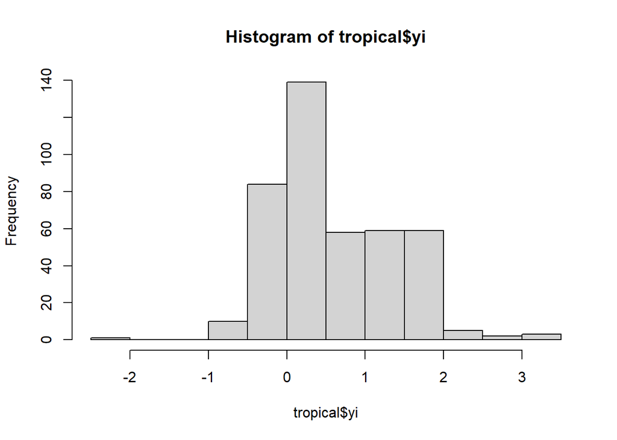

```r
hist(tropical$yi)
```

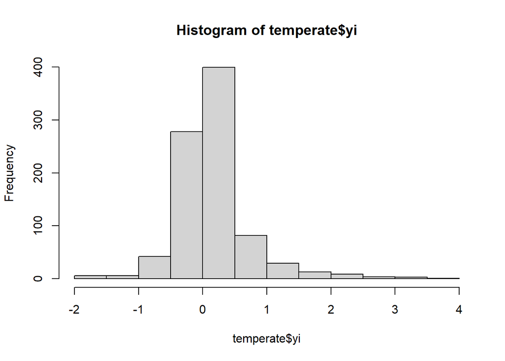

```r
hist(temperate$yi) #distribution looks ok
```

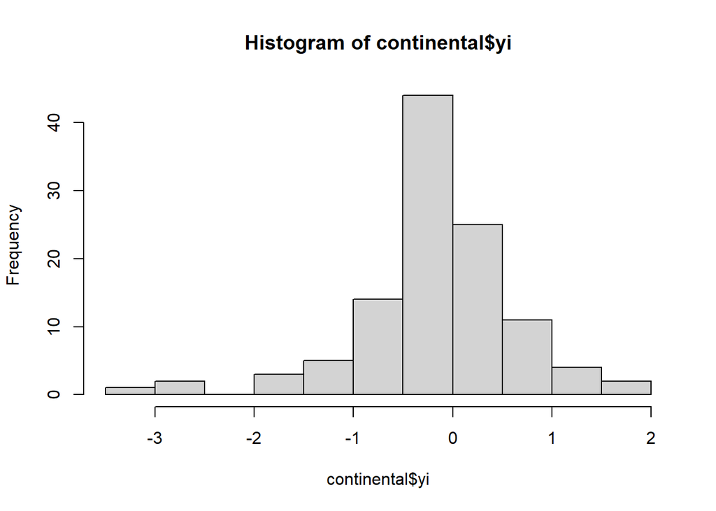

```r
hist(continental$yi) #distribution looks OK
```

```r
library(lme4)
library(lmerTest)
lm_trop<- lmer(yi~ Study_duration_months + ( 1 | Study/Tree_species), data= tropical)
summary(lm_trop)
```

```
## Linear mixed model fit by REML. t-tests use Satterthwaite's method [
## lmerModLmerTest]
## Formula: yi ~ Study_duration_months + (1 | Study/Tree_species)
##    Data: tropical
##
## REML criterion at convergence: 710.2
##
## Scaled residuals:
##     Min      1Q  Median      3Q     Max
## -3.9394 -0.5044 -0.0654  0.3662  5.7114
##
## Random effects:
##  Groups             Name        Variance Std.Dev.
##  Tree_species:Study (Intercept) 0.04883  0.2210
##  Study              (Intercept) 0.22405  0.4733
##  Residual                       0.26963  0.5193
## Number of obs: 420, groups:  Tree_species:Study, 57; Study, 9
##
## Fixed effects:
##                        Estimate Std. Error        df t value Pr(>|t|)
## (Intercept)           3.952e-01  1.854e-01 1.135e+01   2.132   0.0557 .
## Study_duration_months 4.709e-03  3.955e-03 4.179e+02   1.191   0.2345
## ---
## Signif. codes:  0 '***' 0.001 '**' 0.01 '*' 0.05 '.' 0.1 ' ' 1
##
## Correlation of Fixed Effects:
##             (Intr)
## Stdy_drtn_m -0.333
```